# Introduction

# Filter raw data using BigQuery

We preprocess the raw data by loading them into Google's BigQuery, which allows us to quickly explore and filter data and export to CSV. Below is a sample query we used.

SELECT latitude, longitude, categories FROM raw.food_venues WHERE latitude IS NOT NULL AND longitude IS NOT NULL AND state = "NY" AND city = "New York City"

```python
service_requests = pd.read_csv(os.path.join(dataopen_processed, 'service_requests_filtered.csv'), low_memory=False)
geographic = pd.read_csv(os.path.join(dataopen_raw, 'geographic.csv'))
zipcode = pd.read_csv(os.path.join(dataopen_processed, 'zipcode.csv')).dropna()
food_venues = pd.read_csv(os.path.join(dataopen_processed, 'food_venues_filtered.csv'))
```

```python
complaint_categories = {
    'Rodent': ('Rodent',),
    'Sanitation': ('Dirty Conditions', 'Sanitation Condition'),
    'Air Quality': ('Asbestos', 'Mold', 'Indoor Air Quality', 'Smoking'),
    'Food Quality': ('Food Establishment', 'Food Poisoning', 'Drinking Water', 'Calorie Labeling', 'Trans Fat', 'Water System', 'Water Quality', 'Annual Inspection', 'Annual/Cycle Inspection')
}
```

```python
def get_complaint_category(row):
    for category, complaint_types in complaint_categories.items():
        if row.complaint_type in complaint_types:
            return category

service_requests = service_requests.assign(complaint_category=service_requests.apply(lambda row: get_complaint_category(row), axis=1).values)
service_requests[service_requests.complaint_category.notnull()]
```

|  | created_date | closed_date | complaint_type | incident_zip | status | due_date | resolution_date | latitude | longitude | complaint_category |
| --- | --- | --- | --- | --- | --- | --- | --- | --- | --- | --- |
| 1 | 12/08/2015 07:11:53 AM | NaN | Mold | 10454.0 | Open | 01/22/2016 07:11:53 AM | NaN | 40.802237 | -73.907201 | Air Quality |
| 2 | 06/16/2013 07:44:29 PM | NaN | Mold | 10455.0 | Open | 07/31/2013 07:44:29 PM | NaN | 40.818507 | -73.914472 | Air Quality |
| 3 | 07/29/2015 10:51:22 AM | NaN | Mold | 10474.0 | Open | 09/12/2015 10:51:22 AM | NaN | 40.809505 | -73.895038 | Air Quality |
| 4 | 07/15/2015 11:00:52 AM | NaN | Mold | 10456.0 | Open | 08/29/2015 11:00:52 AM | NaN | 40.834044 | -73.896705 | Air Quality |
| 5 | 06/16/2016 10:47:21 AM | NaN | Mold | 10451.0 | Open | 07/31/2016 10:47:21 AM | NaN | 40.822433 | -73.911635 | Air Quality |
| 6 | 12/07/2013 07:41:00 PM | NaN | Mold | 10456.0 | Assigned | 01/21/2014 07:41:00 PM | 01/02/2014 11:25:48 AM | 40.835570 | -73.909662 | Air Quality |
| 7 | 05/12/2015 01:00:20 PM | NaN | Mold | 10453.0 | Open | 06/26/2015 01:00:20 PM | NaN | 40.855242 | -73.907210 | Air Quality |
| 8 | 12/05/2014 03:33:15 AM | NaN | Mold | 10453.0 | Open | 01/19/2015 03:33:15 AM | NaN | 40.853120 | -73.909121 | Air Quality |
| 9 | 11/10/2015 01:18:25 PM | NaN | Mold | 10453.0 | Open | 12/25/2015 01:18:25 PM | NaN | 40.850827 | -73.919397 | Air Quality |
| 10 | 12/02/2013 09:45:03 AM | NaN | Mold | 10453.0 | Assigned | 01/16/2014 09:45:03 AM | 01/02/2014 11:22:30 AM | 40.852326 | -73.908732 | Air Quality |
| 11 | 09/19/2013 12:57:16 PM | NaN | Mold | 10468.0 | Open | 11/03/2013 12:57:16 PM | NaN | 40.862444 | -73.897142 | Air Quality |
| 12 | 05/01/2015 12:02:12 AM | NaN | Mold | 10460.0 | Open | 06/15/2015 12:02:12 AM | NaN | 40.839793 | -73.881232 | Air Quality |
| 13 | 08/11/2015 12:41:32 PM | NaN | Mold | 10457.0 | Open | 09/25/2015 12:41:32 PM | NaN | 40.846932 | -73.895099 | Air Quality |
| 14 | 07/26/2012 09:48:30 AM | NaN | Mold | 10460.0 | Assigned | 09/09/2012 09:48:30 AM | 08/20/2012 03:08:26 PM | 40.844498 | -73.881473 | Air Quality |
| 15 | 09/17/2015 12:11:30 PM | NaN | Mold | 10460.0 | Closed | 11/01/2015 12:11:30 PM | 09/17/2015 03:43:39 PM | 40.841153 | -73.879864 | Air Quality |
| 16 | 08/11/2015 11:52:39 AM | NaN | Mold | 10458.0 | Open | 09/25/2015 11:52:39 AM | NaN | 40.874204 | -73.884457 | Air Quality |
| 17 | 05/23/2015 08:59:14 PM | NaN | Mold | 10468.0 | Open | 07/07/2015 08:59:14 PM | NaN | 40.863044 | -73.898551 | Air Quality |
| 18 | 08/13/2015 08:39:17 AM | NaN | Mold | 10463.0 | Open | 09/27/2015 08:39:17 AM | NaN | 40.870877 | -73.904487 | Air Quality |
| 19 | 07/29/2013 09:07:01 PM | NaN | Mold | 10467.0 | Assigned | 09/12/2013 09:07:01 PM | 11/07/2013 10:15:51 AM | 40.878618 | -73.871504 | Air Quality |
| 20 | 02/28/2014 04:26:48 PM | NaN | Mold | 10458.0 | Assigned | 04/14/2014 04:26:48 PM | 04/14/2014 03:16:31 PM | 40.863191 | -73.891056 | Air Quality |
| 21 | 01/21/2015 10:56:40 AM | NaN | Mold | 10463.0 | Open | 03/07/2015 10:56:40 AM | NaN | 40.880750 | -73.908292 | Air Quality |
| 22 | 03/10/2015 10:27:42 AM | NaN | Mold | 10463.0 | Open | 04/24/2015 10:27:42 AM | NaN | 40.880298 | -73.902738 | Air Quality |
| 23 | 02/26/2015 12:17:33 AM | NaN | Mold | 10463.0 | Open | 04/12/2015 12:17:33 AM | NaN | 40.880750 | -73.908292 | Air Quality |
| 24 | 04/10/2015 05:58:15 PM | NaN | Mold | 10463.0 | Open | 05/25/2015 05:58:15 PM | NaN | 40.880750 | -73.908292 | Air Quality |
| 25 | 05/20/2015 02:11:21 PM | NaN | Mold | 10463.0 | Open | 07/04/2015 02:11:21 PM | NaN | 40.879380 | -73.908648 | Air Quality |
| 26 | 05/04/2015 10:27:10 AM | NaN | Mold | 10463.0 | Open | 06/18/2015 10:27:10 AM | NaN | 40.883664 | -73.910407 | Air Quality |
| 27 | 06/26/2015 02:43:33 PM | NaN | Mold | 10462.0 | Open | 08/10/2015 02:43:33 PM | NaN | 40.835442 | -73.852033 | Air Quality |
| 28 | 11/03/2014 03:49:17 PM | NaN | Mold | 10465.0 | Assigned | 12/18/2014 03:49:17 PM | 11/12/2014 09:18:10 AM | 40.821794 | -73.809588 | Air Quality |
| 29 | 12/29/2014 01:54:04 PM | NaN | Mold | 10461.0 | Open | 02/12/2015 01:54:04 PM | NaN | 40.846234 | -73.833312 | Air Quality |
| 30 | 08/19/2015 03:03:59 PM | NaN | Mold | 10465.0 | Open | 10/03/2015 03:03:59 PM | NaN | 40.821794 | -73.809588 | Air Quality |
| ... | ... | ... | ... | ... | ... | ... | ... | ... | ... | ... |
| 872388 | 12/30/2016 01:40:00 PM | 12/31/2016 12:00:00 PM | Sanitation Condition | 10301.0 | Closed | NaN | 12/31/2016 12:00:00 PM | 40.640020 | -74.094282 | Sanitation |
| 872389 | 12/30/2016 02:06:00 PM | 12/31/2016 12:00:00 PM | Sanitation Condition | 10314.0 | Closed | NaN | 12/31/2016 12:00:00 PM | 40.587836 | -74.148563 | Sanitation |
| 872390 | 12/29/2016 11:05:00 AM | 12/31/2016 12:00:00 PM | Sanitation Condition | 10306.0 | Closed | NaN | 12/31/2016 12:00:00 PM | 40.557713 | -74.114556 | Sanitation |
| 872391 | 12/29/2016 02:28:00 PM | 12/31/2016 12:00:00 PM | Sanitation Condition | 10309.0 | Closed | NaN | 12/31/2016 12:00:00 PM | 40.537196 | -74.223789 | Sanitation |
| 872392 | 12/30/2016 08:13:00 AM | 12/31/2016 12:00:00 PM | Sanitation Condition | 10309.0 | Closed | NaN | 12/31/2016 12:00:00 PM | 40.548174 | -74.212927 | Sanitation |
| 872393 | 12/30/2016 06:18:00 AM | 12/31/2016 12:00:00 PM | Sanitation Condition | 10309.0 | Closed | NaN | 12/31/2016 12:00:00 PM | 40.551619 | -74.218537 | Sanitation |
| 872394 | 12/29/2016 07:51:00 AM | 12/31/2016 12:00:00 PM | Sanitation Condition | 10309.0 | Closed | NaN | 12/31/2016 12:00:00 PM | 40.521027 | -74.205866 | Sanitation |
| 872395 | 12/29/2017 03:46:00 PM | 12/31/2017 12:00:00 PM | Sanitation Condition | 10468.0 | Closed | NaN | 12/31/2017 12:00:00 PM | 40.861916 | -73.908231 | Sanitation |
| 872396 | 12/29/2017 06:20:00 PM | 12/31/2017 12:00:00 PM | Sanitation Condition | 10461.0 | Closed | NaN | 12/31/2017 12:00:00 PM | 40.849478 | -73.833105 | Sanitation |
| 872397 | 12/28/2017 03:35:00 PM | 12/31/2017 12:00:00 PM | Sanitation Condition | 10465.0 | Closed | NaN | 12/31/2017 12:00:00 PM | 40.820710 | -73.818208 | Sanitation |
| 872398 | 12/27/2017 09:39:00 PM | 12/31/2017 12:00:00 PM | Sanitation Condition | 10475.0 | Closed | NaN | 12/31/2017 12:00:00 PM | 40.880872 | -73.826040 | Sanitation |
| 872399 | 12/26/2017 02:35:00 PM | 12/31/2017 12:00:00 PM | Sanitation Condition | 10465.0 | Closed | NaN | 12/31/2017 12:00:00 PM | 40.814914 | -73.828275 | Sanitation |
| 872400 | 12/30/2017 08:34:00 PM | 12/31/2017 12:00:00 PM | Sanitation Condition | 10467.0 | Closed | NaN | 12/31/2017 12:00:00 PM | 40.859583 | -73.866527 | Sanitation |
| 872401 | 12/23/2017 12:23:00 PM | 12/31/2017 12:00:00 PM | Sanitation Condition | 11435.0 | Closed | NaN | 12/31/2017 12:00:00 PM | 40.711020 | -73.814042 | Sanitation |
| 872402 | 12/29/2017 12:25:00 PM | 12/31/2017 12:00:00 PM | Sanitation Condition | 11432.0 | Closed | NaN | 12/31/2017 12:00:00 PM | 40.719185 | -73.800679 | Sanitation |
| 872403 | 12/29/2017 08:12:00 AM | 12/31/2017 12:00:00 PM | Sanitation Condition | 11225.0 | Closed | NaN | 12/31/2017 12:00:00 PM | 40.669339 | -73.960675 | Sanitation |
| 872404 | 12/29/2017 08:01:00 AM | 12/31/2017 12:00:00 PM | Sanitation Condition | 11225.0 | Closed | NaN | 12/31/2017 12:00:00 PM | 40.661117 | -73.958110 | Sanitation |
| 872405 | 12/27/2017 12:29:00 PM | 12/31/2017 12:00:00 PM | Sanitation Condition | 11203.0 | Closed | NaN | 12/31/2017 12:00:00 PM | 40.658055 | -73.936865 | Sanitation |
| 872406 | 12/27/2017 07:51:00 AM | 12/31/2017 12:00:00 PM | Sanitation Condition | 11225.0 | Closed | NaN | 12/31/2017 12:00:00 PM | 40.668153 | -73.952281 | Sanitation |
| 872407 | 12/27/2017 10:34:00 AM | 12/31/2017 12:00:00 PM | Sanitation Condition | 11225.0 | Closed | NaN | 12/31/2017 12:00:00 PM | 40.664184 | -73.946422 | Sanitation |
| 872408 | 12/29/2017 06:26:00 PM | 12/31/2017 12:00:00 PM | Sanitation Condition | 11209.0 | Closed | NaN | 12/31/2017 12:00:00 PM | 40.634659 | -74.029439 | Sanitation |
| 872409 | 12/30/2017 10:54:00 AM | 12/31/2017 12:00:00 PM | Sanitation Condition | 11220.0 | Closed | NaN | 12/31/2017 12:00:00 PM | 40.638625 | -74.027153 | Sanitation |
| 872410 | 12/29/2017 12:00:00 PM | 12/31/2017 12:00:00 PM | Sanitation Condition | 11229.0 | Closed | NaN | 12/31/2017 12:00:00 PM | 40.603179 | -73.937717 | Sanitation |
| 872411 | 12/30/2017 03:20:00 AM | 12/31/2017 12:00:00 PM | Sanitation Condition | 11236.0 | Closed | NaN | 12/31/2017 12:00:00 PM | 40.645813 | -73.918301 | Sanitation |
| 872412 | 12/29/2017 01:53:00 PM | 12/31/2017 12:00:00 PM | Sanitation Condition | 10013.0 | Closed | NaN | 12/31/2017 12:00:00 PM | 40.718803 | -74.010400 | Sanitation |
| 872413 | 12/28/2017 05:09:00 PM | 12/31/2017 12:00:00 PM | Sanitation Condition | 10009.0 | Closed | NaN | 12/31/2017 12:00:00 PM | 40.726249 | -73.984024 | Sanitation |
| 872414 | 12/30/2017 09:02:00 AM | 12/31/2017 12:00:00 PM | Sanitation Condition | 10002.0 | Closed | NaN | 12/31/2017 12:00:00 PM | 40.721287 | -73.987976 | Sanitation |
| 872415 | 12/27/2017 12:35:00 PM | 12/31/2017 12:00:00 PM | Sanitation Condition | 10309.0 | Closed | NaN | 12/31/2017 12:00:00 PM | 40.525456 | -74.218574 | Sanitation |
| 872416 | 12/28/2017 03:53:00 AM | 12/31/2017 12:00:00 PM | Sanitation Condition | 10309.0 | Closed | NaN | 12/31/2017 12:00:00 PM | 40.514969 | -74.196741 | Sanitation |
| 872417 | 12/31/2017 12:24:00 PM | 12/31/2017 12:24:00 PM | Sanitation Condition | 10013.0 | Closed | NaN | 12/31/2017 12:24:00 PM | 40.718548 | -74.000437 | Sanitation |

872416 rows × 10 columns

```python
demographics = pd.read_csv(os.path.join(dataopen_processed, 'demographics_processed.csv')).dropna();
```

# Map events to NTAs

The following code uses geopandas's space join to determine if a Coordinate is covered by a Polygon defined by its boundary vertices.

```python
from shapely import geometry

nta_polygons = {}
for nta_code in geographic.columns:
    vertices = geographic[nta_code].dropna()
    nta_polygons[nta_code] = geometry.Polygon([[vertices[i], vertices[i+1]] for i in range(0, len(vertices), 2)])
```

```python
nta = pd.DataFrame(list(nta_polygons.items()), columns=['nta_code', 'polygon'])
nta.reset_index();
nta_gpd = gpd.GeoDataFrame(nta, geometry='polygon')
```

```python
def _make_geo(dataframe):
    dataframe['Coordinates'] = list(zip(dataframe.longitude, dataframe.latitude))
    dataframe['Coordinates'] = dataframe['Coordinates'].apply(geometry.Point)
    service_requests.reset_index();
    return gpd.GeoDataFrame(dataframe, geometry='Coordinates')

def make_nta(dataframe):
    geoed = _make_geo(dataframe)
    return sjoin(geoed, nta_gpd)
```

```python
def to_csv(dataframe, name):
    name = name.lower()
    if not name.endswith('.csv'):
        name += '.csv'
    dataframe.to_csv(os.path.join(dataopen_processed, name), sep=',', encoding='utf-8', index=False, index_label=False)
```

```python
service_requests_nta = make_nta(service_requests)
to_csv(service_requests_nta, 'service_requests_nta')
```

```python
zipcode_nta = make_nta(zipcode)
to_csv(zipcode_nta, 'zipcode_nta')
```

```python
food_venues_nta = make_nta(food_venues)
to_csv(food_venues_nta, 'food_venues_nta')
```

```python
nta_complaint_category = service_requests_nta.groupby(['nta_code', 'complaint_category']).size().reset_index(name='counts')
```

```python
counts = pd.pivot_table(nta_complaint_category, index='nta_code', columns='complaint_category');
counts.columns=['Air Quality', 'Food Quality', 'Rodent', 'Sanitation']
counts.head()
```

| nta_code | Air Quality | Food Quality | Rodent | Sanitation |
| --- | --- | --- | --- | --- |
| BK09 | 211.0 | 394.0 | 374.0 | 708.0 |
| BK17 | 491.0 | 687.0 | 1024.0 | 4692.0 |
| BK19 | 286.0 | 542.0 | 889.0 | 2348.0 |
| BK21 | 245.0 | 381.0 | 481.0 | 1223.0 |
| BK23 | 104.0 | 119.0 | 141.0 | 165.0 |

## Notice that most complaints are about Rodent and Sanitation.

```python
nta_complaint_category.groupby('complaint_category').agg('sum')
```

| complaint_category | counts |
| --- | --- |
| Air Quality | 54669 |
| Food Quality | 85780 |
| Rodent | 194857 |
| Sanitation | 471462 |

```python
feature_cols = ['median_age', 'people_per_acre',
                'median_income', 'mean_income',
                'Percent_old', 'Percent_young', 'Percent_rich',
                'Percent_poor']

train_df = demographics.merge(counts, left_on='nta_code', right_on='nta_code').dropna()
```

```python
train_df['Air Quality Normalized'] = train_df['Air Quality'] / train_df['households']
train_df['Food Quality Normalized'] = train_df['Food Quality'] / train_df['households']
train_df['Rodent Normalized'] = train_df['Rodent'] / train_df['households']
train_df['Sanitation Normalized'] = train_df['Sanitation'] / train_df['households']
```

```python
train_df.sample(10)
```

|  | Unnamed: 0 | nta_name | borough | nta_code | population | median_age | people_per_acre | households | median_income | mean_income | ... | Percent_rich | Percent_poor | Air Quality | Food Quality | Rodent | Sanitation | Air Quality Normalized | Food Quality Normalized | Rodent Normalized | Sanitation Normalized |
| --- | --- | --- | --- | --- | --- | --- | --- | --- | --- | --- | --- | --- | --- | --- | --- | --- | --- | --- | --- | --- | --- |
| 78 | 81 | Hollis | Queens | QN07 | 20269 | 37 | 38.6 | 6265 | 59368 | 75975 | ... | 0.287470 | 0.300399 | 76.0 | 93.0 | 447.0 | 2066.0 | 0.012131 | 0.014844 | 0.071349 | 0.329769 |
| 2 | 2 | Arden Heights | Staten Island | SI48 | 25238 | 39 | 21.8 | 8960 | 89570 | 101627 | ... | 0.425000 | 0.157701 | 32.0 | 52.0 | 537.0 | 1422.0 | 0.003571 | 0.005804 | 0.059933 | 0.158705 |
| 87 | 90 | Kew Gardens | Queens | QN60 | 23278 | 38 | 49.6 | 10106 | 65035 | 79705 | ... | 0.283792 | 0.267762 | 229.0 | 264.0 | 307.0 | 1245.0 | 0.022660 | 0.026123 | 0.030378 | 0.123194 |
| 91 | 94 | Lenox Hill-Roosevelt Island | Manhattan | MN31 | 80771 | 37 | 157.8 | 43237 | 98797 | 157345 | ... | 0.494576 | 0.184032 | 32.0 | 43.0 | 25.0 | 16.0 | 0.000740 | 0.000995 | 0.000578 | 0.000370 |
| 23 | 24 | Bushwick South | Brooklyn | BK78 | 72101 | 30 | 78.1 | 25575 | 37285 | 49696 | ... | 0.122385 | 0.476989 | 414.0 | 500.0 | 3998.0 | 5662.0 | 0.016188 | 0.019550 | 0.156325 | 0.221388 |
| 58 | 61 | Flatbush | Brooklyn | BK42 | 105804 | 34 | 101.9 | 37722 | 45332 | 60833 | ... | 0.161736 | 0.386963 | 885.0 | 786.0 | 2243.0 | 5157.0 | 0.023461 | 0.020837 | 0.059461 | 0.136711 |
| 29 | 31 | Chinatown | Manhattan | MN27 | 47844 | 39 | 144.0 | 17922 | 35908 | 62270 | ... | 0.176041 | 0.492970 | 709.0 | 1510.0 | 1425.0 | 2423.0 | 0.039560 | 0.084254 | 0.079511 | 0.135197 |
| 31 | 33 | Clinton | Manhattan | MN15 | 45884 | 37 | 108.6 | 25095 | 73591 | 106168 | ... | 0.379279 | 0.288743 | 852.0 | 1486.0 | 1527.0 | 3061.0 | 0.033951 | 0.059215 | 0.060849 | 0.121976 |
| 154 | 164 | Todt Hill-Emerson Hill-Heartland Village-Light... | Staten Island | SI24 | 30714 | 43 | 7.3 | 11300 | 80761 | 109101 | ... | 0.404867 | 0.199115 | 82.0 | 237.0 | 434.0 | 2553.0 | 0.007257 | 0.020973 | 0.038407 | 0.225929 |
| 75 | 78 | Hamilton Heights | Manhattan | MN04 | 48520 | 34 | 132.1 | 18761 | 39019 | 58015 | ... | 0.153936 | 0.466180 | 1129.0 | 384.0 | 2524.0 | 1655.0 | 0.060178 | 0.020468 | 0.134534 | 0.088215 |

10 rows × 22 columns

```python
train_df.corr()
```

|  | Unnamed: 0 | population | median_age | people_per_acre | households | median_income | mean_income | Percent_old | Percent_young | Percent_rich | Percent_poor | Air Quality | Food Quality | Rodent | Sanitation | Air Quality Normalized | Food Quality Normalized | Rodent Normalized | Sanitation Normalized |
| --- | --- | --- | --- | --- | --- | --- | --- | --- | --- | --- | --- | --- | --- | --- | --- | --- | --- | --- | --- |
| Unnamed: 0 | 1.000000 | -0.046652 | 0.034390 | -0.009454 | -0.030803 | 0.094094 | 0.111464 | 0.054204 | -0.014301 | 0.067009 | -0.057699 | 0.006173 | 0.000912 | -0.043079 | -0.040176 | 0.012572 | 0.001990 | -0.030178 | 0.044878 |
| population | -0.046652 | 1.000000 | -0.175588 | 0.424661 | 0.920416 | -0.103256 | 0.019708 | -0.148966 | -0.009229 | -0.124234 | 0.126715 | 0.576987 | 0.432446 | 0.616088 | 0.630612 | 0.099672 | 0.022923 | 0.025718 | -0.167913 |
| median_age | 0.034390 | -0.175588 | 1.000000 | -0.386354 | -0.037629 | 0.521339 | 0.419304 | 0.913164 | -0.616556 | 0.529106 | -0.617503 | -0.134668 | -0.020395 | -0.384613 | -0.159154 | -0.277416 | -0.045701 | -0.558034 | -0.076050 |
| people_per_acre | -0.009454 | 0.424661 | -0.386354 | 1.000000 | 0.461220 | -0.181946 | 0.009554 | -0.274210 | -0.040440 | -0.209292 | 0.360889 | 0.528973 | 0.284731 | 0.423308 | -0.117843 | 0.447527 | 0.093449 | 0.237427 | -0.560879 |
| households | -0.030803 | 0.920416 | -0.037629 | 0.461220 | 1.000000 | 0.124746 | 0.267835 | -0.009837 | -0.270886 | 0.116081 | -0.038292 | 0.723818 | 0.591040 | 0.605502 | 0.501429 | 0.204622 | 0.139925 | -0.033677 | -0.308013 |
| median_income | 0.094094 | -0.103256 | 0.521339 | -0.181946 | 0.124746 | 1.000000 | 0.936544 | 0.429060 | -0.677589 | 0.981432 | -0.905955 | 0.139631 | 0.333742 | -0.224496 | -0.026287 | -0.014580 | 0.278043 | -0.406432 | 0.027688 |
| mean_income | 0.111464 | 0.019708 | 0.419304 | 0.009554 | 0.267835 | 0.936544 | 1.000000 | 0.387052 | -0.652812 | 0.913803 | -0.744506 | 0.321505 | 0.491206 | -0.097165 | -0.017461 | 0.151644 | 0.386240 | -0.332992 | -0.098656 |
| Percent_old | 0.054204 | -0.148966 | 0.913164 | -0.274210 | -0.009837 | 0.429060 | 0.387052 | 1.000000 | -0.542296 | 0.451833 | -0.470443 | -0.099780 | -0.021015 | -0.396957 | -0.236749 | -0.217113 | -0.049768 | -0.587262 | -0.207777 |
| Percent_young | -0.014301 | -0.009229 | -0.616556 | -0.040440 | -0.270886 | -0.677589 | -0.652812 | -0.542296 | 1.000000 | -0.696799 | 0.671942 | -0.343641 | -0.466002 | 0.126817 | 0.093137 | -0.182333 | -0.367942 | 0.419426 | 0.287259 |
| Percent_rich | 0.067009 | -0.124234 | 0.529106 | -0.209292 | 0.116081 | 0.981432 | 0.913803 | 0.451833 | -0.696799 | 1.000000 | -0.899724 | 0.138851 | 0.329378 | -0.231871 | -0.032714 | -0.009520 | 0.278068 | -0.414792 | 0.031231 |
| Percent_poor | -0.057699 | 0.126715 | -0.617503 | 0.360889 | -0.038292 | -0.905955 | -0.744506 | -0.470443 | 0.671942 | -0.899724 | 1.000000 | 0.032166 | -0.142029 | 0.306574 | -0.062843 | 0.207066 | -0.098801 | 0.486618 | -0.196424 |
| Air Quality | 0.006173 | 0.576987 | -0.134668 | 0.528973 | 0.723818 | 0.139631 | 0.321505 | -0.099780 | -0.343641 | 0.138851 | 0.032166 | 1.000000 | 0.828728 | 0.627789 | 0.290469 | 0.764189 | 0.575906 | 0.194104 | -0.309007 |
| Food Quality | 0.000912 | 0.432446 | -0.020395 | 0.284731 | 0.591040 | 0.333742 | 0.491206 | -0.021015 | -0.466002 | 0.329378 | -0.142029 | 0.828728 | 1.000000 | 0.377772 | 0.320659 | 0.650111 | 0.844579 | 0.008432 | -0.170238 |
| Rodent | -0.043079 | 0.616088 | -0.384613 | 0.423308 | 0.605502 | -0.224496 | -0.097165 | -0.396957 | 0.126817 | -0.231871 | 0.306574 | 0.627789 | 0.377772 | 1.000000 | 0.553501 | 0.369193 | 0.121559 | 0.688209 | -0.014607 |
| Sanitation | -0.040176 | 0.630612 | -0.159154 | -0.117843 | 0.501429 | -0.026287 | -0.017461 | -0.236749 | 0.093137 | -0.032714 | -0.062843 | 0.290469 | 0.320659 | 0.553501 | 1.000000 | 0.016215 | 0.108536 | 0.219817 | 0.540796 |
| Air Quality Normalized | 0.012572 | 0.099672 | -0.277416 | 0.447527 | 0.204622 | -0.014580 | 0.151644 | -0.217113 | -0.182333 | -0.009520 | 0.207066 | 0.764189 | 0.650111 | 0.369193 | 0.016215 | 1.000000 | 0.721284 | 0.367988 | -0.220649 |
| Food Quality Normalized | 0.001990 | 0.022923 | -0.045701 | 0.093449 | 0.139925 | 0.278043 | 0.386240 | -0.049768 | -0.367942 | 0.278068 | -0.098801 | 0.575906 | 0.844579 | 0.121559 | 0.108536 | 0.721284 | 1.000000 | 0.070308 | -0.019356 |
| Rodent Normalized | -0.030178 | 0.025718 | -0.558034 | 0.237427 | -0.033677 | -0.406432 | -0.332992 | -0.587262 | 0.419426 | -0.414792 | 0.486618 | 0.194104 | 0.008432 | 0.688209 | 0.219817 | 0.367988 | 0.070308 | 1.000000 | 0.221821 |
| Sanitation Normalized | 0.044878 | -0.167913 | -0.076050 | -0.560879 | -0.308013 | 0.027688 | -0.098656 | -0.207777 | 0.287259 | 0.031231 | -0.196424 | -0.309007 | -0.170238 | -0.014607 | 0.540796 | -0.220649 | -0.019356 | 0.221821 | 1.000000 |

## Mean_income negatively correlates with Rodent_normalized and sanitation_normalized, which is expected. Surprisingly, a higher mean_income correlates with a higher likelihood of food-quality related complaints.

```python
import warnings
warnings.filterwarnings('ignore')

import os

import pandas as pd
import geopandas as gpd
from geopandas import sjoin
```

```python
dataopen_raw = '~/Google Drive/PrincetonDataOpen/'
dataopen_processed = os.path.join(dataopen_raw, 'processed')
```

# Filter raw data using BigQuery

We preprocess the raw data by loading them into Google's BigQuery, which allows us to quickly explore and filter data and export to CSV. Below is a sample query we used.

SELECT latitude, longitude, categories FROM raw.food_venues WHERE latitude IS NOT NULL AND longitude IS NOT NULL AND state = "NY" AND city = "New York City"

```python
service_requests = pd.read_csv(os.path.join(dataopen_processed, 'service_requests_filtered.csv'), low_memory=False)
geographic = pd.read_csv(os.path.join(dataopen_raw, 'geographic.csv'))
zipcode = pd.read_csv(os.path.join(dataopen_processed, 'zipcode.csv')).dropna()
food_venues = pd.read_csv(os.path.join(dataopen_processed, 'food_venues_filtered.csv'))
```

```python
complaint_categories = {
    'Rodent': ('Rodent',),
    'Sanitation': ('Dirty Conditions', 'Sanitation Condition'),
    'Air Quality': ('Asbestos', 'Mold', 'Indoor Air Quality', 'Smoking'),
    'Food Quality': ('Food Establishment', 'Food Poisoning', 'Drinking Water', 'Calorie Labeling', 'Trans Fat', 'Water System', 'Water Quality', 'Annual Inspection', 'Annual/Cycle Inspection')
}
```

```python
def get_complaint_category(row):
    for category, complaint_types in complaint_categories.items():
        if row.complaint_type in complaint_types:
            return category

service_requests = service_requests.assign(complaint_category=service_requests.apply(lambda row: get_complaint_category(row), axis=1).values)
service_requests[service_requests.complaint_category.notnull()]
```

|  | created_date | closed_date | complaint_type | incident_zip | status | due_date | resolution_date | latitude | longitude | complaint_category |
| --- | --- | --- | --- | --- | --- | --- | --- | --- | --- | --- |
| 1 | 12/08/2015 07:11:53 AM | NaN | Mold | 10454.0 | Open | 01/22/2016 07:11:53 AM | NaN | 40.802237 | -73.907201 | Air Quality |
| 2 | 06/16/2013 07:44:29 PM | NaN | Mold | 10455.0 | Open | 07/31/2013 07:44:29 PM | NaN | 40.818507 | -73.914472 | Air Quality |
| 3 | 07/29/2015 10:51:22 AM | NaN | Mold | 10474.0 | Open | 09/12/2015 10:51:22 AM | NaN | 40.809505 | -73.895038 | Air Quality |
| 4 | 07/15/2015 11:00:52 AM | NaN | Mold | 10456.0 | Open | 08/29/2015 11:00:52 AM | NaN | 40.834044 | -73.896705 | Air Quality |
| 5 | 06/16/2016 10:47:21 AM | NaN | Mold | 10451.0 | Open | 07/31/2016 10:47:21 AM | NaN | 40.822433 | -73.911635 | Air Quality |
| 6 | 12/07/2013 07:41:00 PM | NaN | Mold | 10456.0 | Assigned | 01/21/2014 07:41:00 PM | 01/02/2014 11:25:48 AM | 40.835570 | -73.909662 | Air Quality |
| 7 | 05/12/2015 01:00:20 PM | NaN | Mold | 10453.0 | Open | 06/26/2015 01:00:20 PM | NaN | 40.855242 | -73.907210 | Air Quality |
| 8 | 12/05/2014 03:33:15 AM | NaN | Mold | 10453.0 | Open | 01/19/2015 03:33:15 AM | NaN | 40.853120 | -73.909121 | Air Quality |
| 9 | 11/10/2015 01:18:25 PM | NaN | Mold | 10453.0 | Open | 12/25/2015 01:18:25 PM | NaN | 40.850827 | -73.919397 | Air Quality |
| 10 | 12/02/2013 09:45:03 AM | NaN | Mold | 10453.0 | Assigned | 01/16/2014 09:45:03 AM | 01/02/2014 11:22:30 AM | 40.852326 | -73.908732 | Air Quality |
| 11 | 09/19/2013 12:57:16 PM | NaN | Mold | 10468.0 | Open | 11/03/2013 12:57:16 PM | NaN | 40.862444 | -73.897142 | Air Quality |
| 12 | 05/01/2015 12:02:12 AM | NaN | Mold | 10460.0 | Open | 06/15/2015 12:02:12 AM | NaN | 40.839793 | -73.881232 | Air Quality |
| 13 | 08/11/2015 12:41:32 PM | NaN | Mold | 10457.0 | Open | 09/25/2015 12:41:32 PM | NaN | 40.846932 | -73.895099 | Air Quality |
| 14 | 07/26/2012 09:48:30 AM | NaN | Mold | 10460.0 | Assigned | 09/09/2012 09:48:30 AM | 08/20/2012 03:08:26 PM | 40.844498 | -73.881473 | Air Quality |
| 15 | 09/17/2015 12:11:30 PM | NaN | Mold | 10460.0 | Closed | 11/01/2015 12:11:30 PM | 09/17/2015 03:43:39 PM | 40.841153 | -73.879864 | Air Quality |
| 16 | 08/11/2015 11:52:39 AM | NaN | Mold | 10458.0 | Open | 09/25/2015 11:52:39 AM | NaN | 40.874204 | -73.884457 | Air Quality |
| 17 | 05/23/2015 08:59:14 PM | NaN | Mold | 10468.0 | Open | 07/07/2015 08:59:14 PM | NaN | 40.863044 | -73.898551 | Air Quality |
| 18 | 08/13/2015 08:39:17 AM | NaN | Mold | 10463.0 | Open | 09/27/2015 08:39:17 AM | NaN | 40.870877 | -73.904487 | Air Quality |
| 19 | 07/29/2013 09:07:01 PM | NaN | Mold | 10467.0 | Assigned | 09/12/2013 09:07:01 PM | 11/07/2013 10:15:51 AM | 40.878618 | -73.871504 | Air Quality |
| 20 | 02/28/2014 04:26:48 PM | NaN | Mold | 10458.0 | Assigned | 04/14/2014 04:26:48 PM | 04/14/2014 03:16:31 PM | 40.863191 | -73.891056 | Air Quality |
| 21 | 01/21/2015 10:56:40 AM | NaN | Mold | 10463.0 | Open | 03/07/2015 10:56:40 AM | NaN | 40.880750 | -73.908292 | Air Quality |
| 22 | 03/10/2015 10:27:42 AM | NaN | Mold | 10463.0 | Open | 04/24/2015 10:27:42 AM | NaN | 40.880298 | -73.902738 | Air Quality |
| 23 | 02/26/2015 12:17:33 AM | NaN | Mold | 10463.0 | Open | 04/12/2015 12:17:33 AM | NaN | 40.880750 | -73.908292 | Air Quality |
| 24 | 04/10/2015 05:58:15 PM | NaN | Mold | 10463.0 | Open | 05/25/2015 05:58:15 PM | NaN | 40.880750 | -73.908292 | Air Quality |
| 25 | 05/20/2015 02:11:21 PM | NaN | Mold | 10463.0 | Open | 07/04/2015 02:11:21 PM | NaN | 40.879380 | -73.908648 | Air Quality |
| 26 | 05/04/2015 10:27:10 AM | NaN | Mold | 10463.0 | Open | 06/18/2015 10:27:10 AM | NaN | 40.883664 | -73.910407 | Air Quality |
| 27 | 06/26/2015 02:43:33 PM | NaN | Mold | 10462.0 | Open | 08/10/2015 02:43:33 PM | NaN | 40.835442 | -73.852033 | Air Quality |
| 28 | 11/03/2014 03:49:17 PM | NaN | Mold | 10465.0 | Assigned | 12/18/2014 03:49:17 PM | 11/12/2014 09:18:10 AM | 40.821794 | -73.809588 | Air Quality |
| 29 | 12/29/2014 01:54:04 PM | NaN | Mold | 10461.0 | Open | 02/12/2015 01:54:04 PM | NaN | 40.846234 | -73.833312 | Air Quality |
| 30 | 08/19/2015 03:03:59 PM | NaN | Mold | 10465.0 | Open | 10/03/2015 03:03:59 PM | NaN | 40.821794 | -73.809588 | Air Quality |
| ... | ... | ... | ... | ... | ... | ... | ... | ... | ... | ... |
| 872388 | 12/30/2016 01:40:00 PM | 12/31/2016 12:00:00 PM | Sanitation Condition | 10301.0 | Closed | NaN | 12/31/2016 12:00:00 PM | 40.640020 | -74.094282 | Sanitation |
| 872389 | 12/30/2016 02:06:00 PM | 12/31/2016 12:00:00 PM | Sanitation Condition | 10314.0 | Closed | NaN | 12/31/2016 12:00:00 PM | 40.587836 | -74.148563 | Sanitation |
| 872390 | 12/29/2016 11:05:00 AM | 12/31/2016 12:00:00 PM | Sanitation Condition | 10306.0 | Closed | NaN | 12/31/2016 12:00:00 PM | 40.557713 | -74.114556 | Sanitation |
| 872391 | 12/29/2016 02:28:00 PM | 12/31/2016 12:00:00 PM | Sanitation Condition | 10309.0 | Closed | NaN | 12/31/2016 12:00:00 PM | 40.537196 | -74.223789 | Sanitation |
| 872392 | 12/30/2016 08:13:00 AM | 12/31/2016 12:00:00 PM | Sanitation Condition | 10309.0 | Closed | NaN | 12/31/2016 12:00:00 PM | 40.548174 | -74.212927 | Sanitation |
| 872393 | 12/30/2016 06:18:00 AM | 12/31/2016 12:00:00 PM | Sanitation Condition | 10309.0 | Closed | NaN | 12/31/2016 12:00:00 PM | 40.551619 | -74.218537 | Sanitation |
| 872394 | 12/29/2016 07:51:00 AM | 12/31/2016 12:00:00 PM | Sanitation Condition | 10309.0 | Closed | NaN | 12/31/2016 12:00:00 PM | 40.521027 | -74.205866 | Sanitation |
| 872395 | 12/29/2017 03:46:00 PM | 12/31/2017 12:00:00 PM | Sanitation Condition | 10468.0 | Closed | NaN | 12/31/2017 12:00:00 PM | 40.861916 | -73.908231 | Sanitation |
| 872396 | 12/29/2017 06:20:00 PM | 12/31/2017 12:00:00 PM | Sanitation Condition | 10461.0 | Closed | NaN | 12/31/2017 12:00:00 PM | 40.849478 | -73.833105 | Sanitation |
| 872397 | 12/28/2017 03:35:00 PM | 12/31/2017 12:00:00 PM | Sanitation Condition | 10465.0 | Closed | NaN | 12/31/2017 12:00:00 PM | 40.820710 | -73.818208 | Sanitation |
| 872398 | 12/27/2017 09:39:00 PM | 12/31/2017 12:00:00 PM | Sanitation Condition | 10475.0 | Closed | NaN | 12/31/2017 12:00:00 PM | 40.880872 | -73.826040 | Sanitation |
| 872399 | 12/26/2017 02:35:00 PM | 12/31/2017 12:00:00 PM | Sanitation Condition | 10465.0 | Closed | NaN | 12/31/2017 12:00:00 PM | 40.814914 | -73.828275 | Sanitation |
| 872400 | 12/30/2017 08:34:00 PM | 12/31/2017 12:00:00 PM | Sanitation Condition | 10467.0 | Closed | NaN | 12/31/2017 12:00:00 PM | 40.859583 | -73.866527 | Sanitation |
| 872401 | 12/23/2017 12:23:00 PM | 12/31/2017 12:00:00 PM | Sanitation Condition | 11435.0 | Closed | NaN | 12/31/2017 12:00:00 PM | 40.711020 | -73.814042 | Sanitation |
| 872402 | 12/29/2017 12:25:00 PM | 12/31/2017 12:00:00 PM | Sanitation Condition | 11432.0 | Closed | NaN | 12/31/2017 12:00:00 PM | 40.719185 | -73.800679 | Sanitation |
| 872403 | 12/29/2017 08:12:00 AM | 12/31/2017 12:00:00 PM | Sanitation Condition | 11225.0 | Closed | NaN | 12/31/2017 12:00:00 PM | 40.669339 | -73.960675 | Sanitation |
| 872404 | 12/29/2017 08:01:00 AM | 12/31/2017 12:00:00 PM | Sanitation Condition | 11225.0 | Closed | NaN | 12/31/2017 12:00:00 PM | 40.661117 | -73.958110 | Sanitation |
| 872405 | 12/27/2017 12:29:00 PM | 12/31/2017 12:00:00 PM | Sanitation Condition | 11203.0 | Closed | NaN | 12/31/2017 12:00:00 PM | 40.658055 | -73.936865 | Sanitation |
| 872406 | 12/27/2017 07:51:00 AM | 12/31/2017 12:00:00 PM | Sanitation Condition | 11225.0 | Closed | NaN | 12/31/2017 12:00:00 PM | 40.668153 | -73.952281 | Sanitation |
| 872407 | 12/27/2017 10:34:00 AM | 12/31/2017 12:00:00 PM | Sanitation Condition | 11225.0 | Closed | NaN | 12/31/2017 12:00:00 PM | 40.664184 | -73.946422 | Sanitation |
| 872408 | 12/29/2017 06:26:00 PM | 12/31/2017 12:00:00 PM | Sanitation Condition | 11209.0 | Closed | NaN | 12/31/2017 12:00:00 PM | 40.634659 | -74.029439 | Sanitation |
| 872409 | 12/30/2017 10:54:00 AM | 12/31/2017 12:00:00 PM | Sanitation Condition | 11220.0 | Closed | NaN | 12/31/2017 12:00:00 PM | 40.638625 | -74.027153 | Sanitation |
| 872410 | 12/29/2017 12:00:00 PM | 12/31/2017 12:00:00 PM | Sanitation Condition | 11229.0 | Closed | NaN | 12/31/2017 12:00:00 PM | 40.603179 | -73.937717 | Sanitation |
| 872411 | 12/30/2017 03:20:00 AM | 12/31/2017 12:00:00 PM | Sanitation Condition | 11236.0 | Closed | NaN | 12/31/2017 12:00:00 PM | 40.645813 | -73.918301 | Sanitation |
| 872412 | 12/29/2017 01:53:00 PM | 12/31/2017 12:00:00 PM | Sanitation Condition | 10013.0 | Closed | NaN | 12/31/2017 12:00:00 PM | 40.718803 | -74.010400 | Sanitation |
| 872413 | 12/28/2017 05:09:00 PM | 12/31/2017 12:00:00 PM | Sanitation Condition | 10009.0 | Closed | NaN | 12/31/2017 12:00:00 PM | 40.726249 | -73.984024 | Sanitation |
| 872414 | 12/30/2017 09:02:00 AM | 12/31/2017 12:00:00 PM | Sanitation Condition | 10002.0 | Closed | NaN | 12/31/2017 12:00:00 PM | 40.721287 | -73.987976 | Sanitation |
| 872415 | 12/27/2017 12:35:00 PM | 12/31/2017 12:00:00 PM | Sanitation Condition | 10309.0 | Closed | NaN | 12/31/2017 12:00:00 PM | 40.525456 | -74.218574 | Sanitation |
| 872416 | 12/28/2017 03:53:00 AM | 12/31/2017 12:00:00 PM | Sanitation Condition | 10309.0 | Closed | NaN | 12/31/2017 12:00:00 PM | 40.514969 | -74.196741 | Sanitation |
| 872417 | 12/31/2017 12:24:00 PM | 12/31/2017 12:24:00 PM | Sanitation Condition | 10013.0 | Closed | NaN | 12/31/2017 12:24:00 PM | 40.718548 | -74.000437 | Sanitation |

872416 rows × 10 columns

```python
demographics = pd.read_csv(os.path.join(dataopen_processed, 'demographics_processed.csv')).dropna();
```

# Map events to NTAs

The following code uses geopandas's space join to determine if a Coordinate is covered by a Polygon defined by its boundary vertices.

```python
from shapely import geometry

nta_polygons = {}
for nta_code in geographic.columns:
    vertices = geographic[nta_code].dropna()
    nta_polygons[nta_code] = geometry.Polygon([[vertices[i], vertices[i+1]] for i in range(0, len(vertices), 2)])
```

```python
nta = pd.DataFrame(list(nta_polygons.items()), columns=['nta_code', 'polygon'])
nta.reset_index();
nta_gpd = gpd.GeoDataFrame(nta, geometry='polygon')
```

```python
def _make_geo(dataframe):
    dataframe['Coordinates'] = list(zip(dataframe.longitude, dataframe.latitude))
    dataframe['Coordinates'] = dataframe['Coordinates'].apply(geometry.Point)
    service_requests.reset_index();
    return gpd.GeoDataFrame(dataframe, geometry='Coordinates')

def make_nta(dataframe):
    geoed = _make_geo(dataframe)
    return sjoin(geoed, nta_gpd)
```

```python
def to_csv(dataframe, name):
    name = name.lower()
    if not name.endswith('.csv'):
        name += '.csv'
    dataframe.to_csv(os.path.join(dataopen_processed, name), sep=',', encoding='utf-8', index=False, index_label=False)
```

```python
service_requests_nta = make_nta(service_requests)
to_csv(service_requests_nta, 'service_requests_nta')
```

```python
zipcode_nta = make_nta(zipcode)
to_csv(zipcode_nta, 'zipcode_nta')
```

```python
food_venues_nta = make_nta(food_venues)
to_csv(food_venues_nta, 'food_venues_nta')
```

```python
nta_complaint_category = service_requests_nta.groupby(['nta_code', 'complaint_category']).size().reset_index(name='counts')
```

```python
counts = pd.pivot_table(nta_complaint_category, index='nta_code', columns='complaint_category');
counts.columns=['Air Quality', 'Food Quality', 'Rodent', 'Sanitation']
counts.head()
```

| nta_code | Air Quality | Food Quality | Rodent | Sanitation |
| --- | --- | --- | --- | --- |
| BK09 | 211.0 | 394.0 | 374.0 | 708.0 |
| BK17 | 491.0 | 687.0 | 1024.0 | 4692.0 |
| BK19 | 286.0 | 542.0 | 889.0 | 2348.0 |
| BK21 | 245.0 | 381.0 | 481.0 | 1223.0 |
| BK23 | 104.0 | 119.0 | 141.0 | 165.0 |

## Notice that most complaints are about Rodent and Sanitation.

```python
nta_complaint_category.groupby('complaint_category').agg('sum')
```

| complaint_category | counts |
| --- | --- |
| Air Quality | 54669 |
| Food Quality | 85780 |
| Rodent | 194857 |
| Sanitation | 471462 |

```python
feature_cols = ['median_age', 'people_per_acre',
                'median_income', 'mean_income',
                'Percent_old', 'Percent_young', 'Percent_rich',
                'Percent_poor']

train_df = demographics.merge(counts, left_on='nta_code', right_on='nta_code').dropna()
```

```python
train_df['Air Quality Normalized'] = train_df['Air Quality'] / train_df['households']
train_df['Food Quality Normalized'] = train_df['Food Quality'] / train_df['households']
train_df['Rodent Normalized'] = train_df['Rodent'] / train_df['households']
train_df['Sanitation Normalized'] = train_df['Sanitation'] / train_df['households']
```

```python
train_df.sample(10)
```

|  | Unnamed: 0 | nta_name | borough | nta_code | population | median_age | people_per_acre | households | median_income | mean_income | ... | Percent_rich | Percent_poor | Air Quality | Food Quality | Rodent | Sanitation | Air Quality Normalized | Food Quality Normalized | Rodent Normalized | Sanitation Normalized |
| --- | --- | --- | --- | --- | --- | --- | --- | --- | --- | --- | --- | --- | --- | --- | --- | --- | --- | --- | --- | --- | --- |
| 78 | 81 | Hollis | Queens | QN07 | 20269 | 37 | 38.6 | 6265 | 59368 | 75975 | ... | 0.287470 | 0.300399 | 76.0 | 93.0 | 447.0 | 2066.0 | 0.012131 | 0.014844 | 0.071349 | 0.329769 |
| 2 | 2 | Arden Heights | Staten Island | SI48 | 25238 | 39 | 21.8 | 8960 | 89570 | 101627 | ... | 0.425000 | 0.157701 | 32.0 | 52.0 | 537.0 | 1422.0 | 0.003571 | 0.005804 | 0.059933 | 0.158705 |
| 87 | 90 | Kew Gardens | Queens | QN60 | 23278 | 38 | 49.6 | 10106 | 65035 | 79705 | ... | 0.283792 | 0.267762 | 229.0 | 264.0 | 307.0 | 1245.0 | 0.022660 | 0.026123 | 0.030378 | 0.123194 |
| 91 | 94 | Lenox Hill-Roosevelt Island | Manhattan | MN31 | 80771 | 37 | 157.8 | 43237 | 98797 | 157345 | ... | 0.494576 | 0.184032 | 32.0 | 43.0 | 25.0 | 16.0 | 0.000740 | 0.000995 | 0.000578 | 0.000370 |
| 23 | 24 | Bushwick South | Brooklyn | BK78 | 72101 | 30 | 78.1 | 25575 | 37285 | 49696 | ... | 0.122385 | 0.476989 | 414.0 | 500.0 | 3998.0 | 5662.0 | 0.016188 | 0.019550 | 0.156325 | 0.221388 |
| 58 | 61 | Flatbush | Brooklyn | BK42 | 105804 | 34 | 101.9 | 37722 | 45332 | 60833 | ... | 0.161736 | 0.386963 | 885.0 | 786.0 | 2243.0 | 5157.0 | 0.023461 | 0.020837 | 0.059461 | 0.136711 |
| 29 | 31 | Chinatown | Manhattan | MN27 | 47844 | 39 | 144.0 | 17922 | 35908 | 62270 | ... | 0.176041 | 0.492970 | 709.0 | 1510.0 | 1425.0 | 2423.0 | 0.039560 | 0.084254 | 0.079511 | 0.135197 |
| 31 | 33 | Clinton | Manhattan | MN15 | 45884 | 37 | 108.6 | 25095 | 73591 | 106168 | ... | 0.379279 | 0.288743 | 852.0 | 1486.0 | 1527.0 | 3061.0 | 0.033951 | 0.059215 | 0.060849 | 0.121976 |
| 154 | 164 | Todt Hill-Emerson Hill-Heartland Village-Light... | Staten Island | SI24 | 30714 | 43 | 7.3 | 11300 | 80761 | 109101 | ... | 0.404867 | 0.199115 | 82.0 | 237.0 | 434.0 | 2553.0 | 0.007257 | 0.020973 | 0.038407 | 0.225929 |
| 75 | 78 | Hamilton Heights | Manhattan | MN04 | 48520 | 34 | 132.1 | 18761 | 39019 | 58015 | ... | 0.153936 | 0.466180 | 1129.0 | 384.0 | 2524.0 | 1655.0 | 0.060178 | 0.020468 | 0.134534 | 0.088215 |

10 rows × 22 columns

```python
train_df.corr()
```

|  | Unnamed: 0 | population | median_age | people_per_acre | households | median_income | mean_income | Percent_old | Percent_young | Percent_rich | Percent_poor | Air Quality | Food Quality | Rodent | Sanitation | Air Quality Normalized | Food Quality Normalized | Rodent Normalized | Sanitation Normalized |
| --- | --- | --- | --- | --- | --- | --- | --- | --- | --- | --- | --- | --- | --- | --- | --- | --- | --- | --- | --- |
| Unnamed: 0 | 1.000000 | -0.046652 | 0.034390 | -0.009454 | -0.030803 | 0.094094 | 0.111464 | 0.054204 | -0.014301 | 0.067009 | -0.057699 | 0.006173 | 0.000912 | -0.043079 | -0.040176 | 0.012572 | 0.001990 | -0.030178 | 0.044878 |
| population | -0.046652 | 1.000000 | -0.175588 | 0.424661 | 0.920416 | -0.103256 | 0.019708 | -0.148966 | -0.009229 | -0.124234 | 0.126715 | 0.576987 | 0.432446 | 0.616088 | 0.630612 | 0.099672 | 0.022923 | 0.025718 | -0.167913 |
| median_age | 0.034390 | -0.175588 | 1.000000 | -0.386354 | -0.037629 | 0.521339 | 0.419304 | 0.913164 | -0.616556 | 0.529106 | -0.617503 | -0.134668 | -0.020395 | -0.384613 | -0.159154 | -0.277416 | -0.045701 | -0.558034 | -0.076050 |
| people_per_acre | -0.009454 | 0.424661 | -0.386354 | 1.000000 | 0.461220 | -0.181946 | 0.009554 | -0.274210 | -0.040440 | -0.209292 | 0.360889 | 0.528973 | 0.284731 | 0.423308 | -0.117843 | 0.447527 | 0.093449 | 0.237427 | -0.560879 |
| households | -0.030803 | 0.920416 | -0.037629 | 0.461220 | 1.000000 | 0.124746 | 0.267835 | -0.009837 | -0.270886 | 0.116081 | -0.038292 | 0.723818 | 0.591040 | 0.605502 | 0.501429 | 0.204622 | 0.139925 | -0.033677 | -0.308013 |
| median_income | 0.094094 | -0.103256 | 0.521339 | -0.181946 | 0.124746 | 1.000000 | 0.936544 | 0.429060 | -0.677589 | 0.981432 | -0.905955 | 0.139631 | 0.333742 | -0.224496 | -0.026287 | -0.014580 | 0.278043 | -0.406432 | 0.027688 |
| mean_income | 0.111464 | 0.019708 | 0.419304 | 0.009554 | 0.267835 | 0.936544 | 1.000000 | 0.387052 | -0.652812 | 0.913803 | -0.744506 | 0.321505 | 0.491206 | -0.097165 | -0.017461 | 0.151644 | 0.386240 | -0.332992 | -0.098656 |
| Percent_old | 0.054204 | -0.148966 | 0.913164 | -0.274210 | -0.009837 | 0.429060 | 0.387052 | 1.000000 | -0.542296 | 0.451833 | -0.470443 | -0.099780 | -0.021015 | -0.396957 | -0.236749 | -0.217113 | -0.049768 | -0.587262 | -0.207777 |
| Percent_young | -0.014301 | -0.009229 | -0.616556 | -0.040440 | -0.270886 | -0.677589 | -0.652812 | -0.542296 | 1.000000 | -0.696799 | 0.671942 | -0.343641 | -0.466002 | 0.126817 | 0.093137 | -0.182333 | -0.367942 | 0.419426 | 0.287259 |
| Percent_rich | 0.067009 | -0.124234 | 0.529106 | -0.209292 | 0.116081 | 0.981432 | 0.913803 | 0.451833 | -0.696799 | 1.000000 | -0.899724 | 0.138851 | 0.329378 | -0.231871 | -0.032714 | -0.009520 | 0.278068 | -0.414792 | 0.031231 |
| Percent_poor | -0.057699 | 0.126715 | -0.617503 | 0.360889 | -0.038292 | -0.905955 | -0.744506 | -0.470443 | 0.671942 | -0.899724 | 1.000000 | 0.032166 | -0.142029 | 0.306574 | -0.062843 | 0.207066 | -0.098801 | 0.486618 | -0.196424 |
| Air Quality | 0.006173 | 0.576987 | -0.134668 | 0.528973 | 0.723818 | 0.139631 | 0.321505 | -0.099780 | -0.343641 | 0.138851 | 0.032166 | 1.000000 | 0.828728 | 0.627789 | 0.290469 | 0.764189 | 0.575906 | 0.194104 | -0.309007 |
| Food Quality | 0.000912 | 0.432446 | -0.020395 | 0.284731 | 0.591040 | 0.333742 | 0.491206 | -0.021015 | -0.466002 | 0.329378 | -0.142029 | 0.828728 | 1.000000 | 0.377772 | 0.320659 | 0.650111 | 0.844579 | 0.008432 | -0.170238 |
| Rodent | -0.043079 | 0.616088 | -0.384613 | 0.423308 | 0.605502 | -0.224496 | -0.097165 | -0.396957 | 0.126817 | -0.231871 | 0.306574 | 0.627789 | 0.377772 | 1.000000 | 0.553501 | 0.369193 | 0.121559 | 0.688209 | -0.014607 |
| Sanitation | -0.040176 | 0.630612 | -0.159154 | -0.117843 | 0.501429 | -0.026287 | -0.017461 | -0.236749 | 0.093137 | -0.032714 | -0.062843 | 0.290469 | 0.320659 | 0.553501 | 1.000000 | 0.016215 | 0.108536 | 0.219817 | 0.540796 |
| Air Quality Normalized | 0.012572 | 0.099672 | -0.277416 | 0.447527 | 0.204622 | -0.014580 | 0.151644 | -0.217113 | -0.182333 | -0.009520 | 0.207066 | 0.764189 | 0.650111 | 0.369193 | 0.016215 | 1.000000 | 0.721284 | 0.367988 | -0.220649 |
| Food Quality Normalized | 0.001990 | 0.022923 | -0.045701 | 0.093449 | 0.139925 | 0.278043 | 0.386240 | -0.049768 | -0.367942 | 0.278068 | -0.098801 | 0.575906 | 0.844579 | 0.121559 | 0.108536 | 0.721284 | 1.000000 | 0.070308 | -0.019356 |
| Rodent Normalized | -0.030178 | 0.025718 | -0.558034 | 0.237427 | -0.033677 | -0.406432 | -0.332992 | -0.587262 | 0.419426 | -0.414792 | 0.486618 | 0.194104 | 0.008432 | 0.688209 | 0.219817 | 0.367988 | 0.070308 | 1.000000 | 0.221821 |
| Sanitation Normalized | 0.044878 | -0.167913 | -0.076050 | -0.560879 | -0.308013 | 0.027688 | -0.098656 | -0.207777 | 0.287259 | 0.031231 | -0.196424 | -0.309007 | -0.170238 | -0.014607 | 0.540796 | -0.220649 | -0.019356 | 0.221821 | 1.000000 |

## Mean_income negatively correlates with Rodent_normalized and sanitation_normalized, which is expected. Surprisingly, a higher mean_income correlates with a higher likelihood of food-quality related complaints.

```python
import pandas as pd
import numpy as np
import matplotlib.pyplot as plt
%matplotlib inline
import statsmodels.api as sm
from IPython.display import Image
```

```python
from collections import Counter
```

```python
path='/Users/candice/Desktop/Datathon Materials/'
```

## Read Food Establishment Data

To analyze the food quality in certain NTA, we used the **food_establishment_inspections_city** dataset and try to find important feature that about the wellness of restaurants in certain area.

```python
df=pd.read_csv('/Users/candice/Desktop/Datathon Materials/food_establishment_inspections_city.csv',encoding='ISO 8859-1')
```

```python
df.head().T
```

|  | 0 | 1 | 2 | 3 | 4 |
| --- | --- | --- | --- | --- | --- |
| name | THE OLD SIAM RESTAURANT AND BAR | DANNY'S PIZZERIA & CAFE | CLUB 101 | PRONTO RESTAURANT | GOOD SHEPHERD SERVICES BRONX DJJ |
| borough | QUEENS | BROOKLYN | MANHATTAN | STATEN ISLAND | BRONX |
| street_name | AUSTIN ST | BUSHWICK AVENUE | PARK AVENUE | RICHMOND AVENUE | UNIVERSITY AVENUE |
| zipcode | 11375 | 11206 | 10178 | 10312 | 10453 |
| phone | 7185446444 | 7183811669 | 2128180263 | 7183562442 | 7185610251 |
| cuisine | Thai | Pizza/Italian | American | Pizza/Italian | American |
| date_inspection | 10/20/15 | 7/12/16 | 5/10/16 | 11/2/16 | 2/8/17 |
| action | Violations were cited in the following area(s). | Violations were cited in the following area(s). | Violations were cited in the following area(s). | Violations were cited in the following area(s). | Violations were cited in the following area(s). |
| violation_code | 06C | 10H | 04L | 02B | 04J |
| description_violation | Food not protected from potential source of co... | Proper sanitization not provided for utensil w... | Evidence of mice or live mice present in facil... | Hot food item not held at or above 140å¼ F. | Appropriately scaled metal stem-type thermomet... |
| crit_or_noncrit | Critical | Not Critical | Critical | Critical | Critical |
| score | 10 | 25 | 11 | 11 | 20 |
| grade | A | NaN | A | A | NaN |
| grade_date | 10/20/15 | NaN | 5/10/16 | 11/2/16 | NaN |
| inspection_type | Cycle Inspection / Initial Inspection | Cycle Inspection / Initial Inspection | Cycle Inspection / Initial Inspection | Cycle Inspection / Initial Inspection | Cycle Inspection / Initial Inspection |

```
The average score is score    19.422357
dtype: float64
```

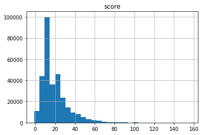

```python
print(df[['score']].hist(bins=30))
print('The average score is',df[['score']].mean())
```

At first glance, we find out the average of score is 19.4 and most restaurants gained a score between [0,20), while there is still some restaurant that has a higher than 60 score. Then we examine the score by year and borough and find out that restaurant score differs in every borough.

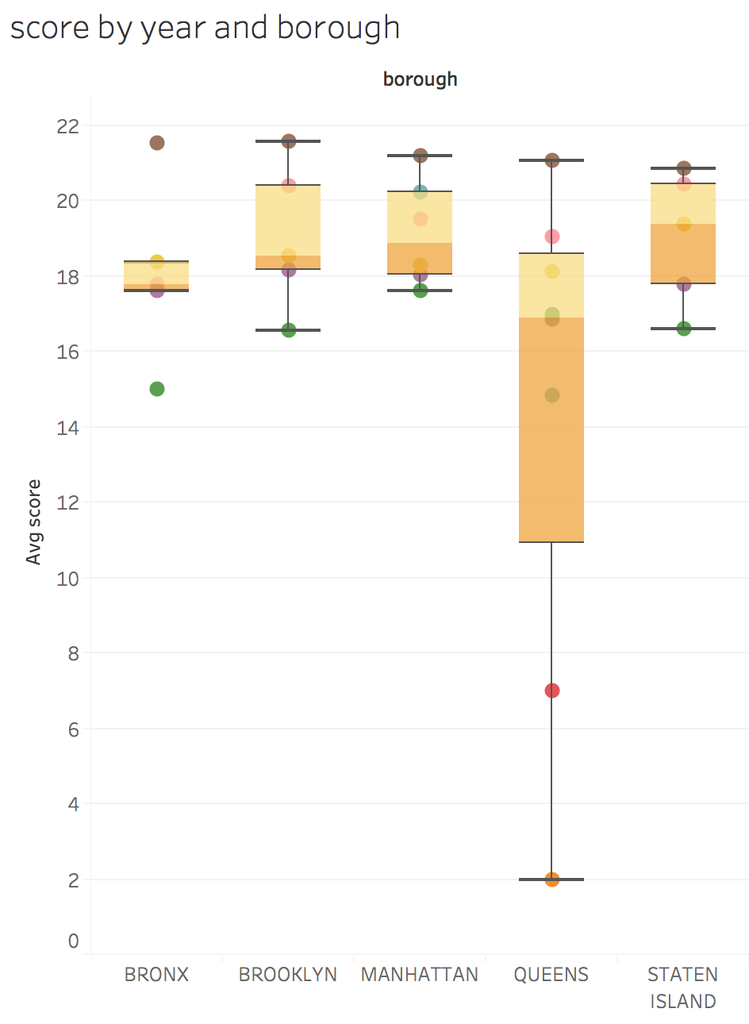

```python
Image(path+"score_by_borough.png",width=500)
```

```python
inspection_type=pd.DataFrame(list(df['inspection_type'].apply(lambda x: str(x).split(' / '))),columns=['inspection1','inspection2'])

df=df.merge(inspection_type,right_index=True,left_index=True)

df['date_inspection']=pd.to_datetime(df['date_inspection'],format='%m/%d/%y')

df['year']=df['date_inspection'].dt.year

Counter(df['year'])

df['month']=df['date_inspection'].dt.month
```

## From Zipcode to NTA

The NYC level restaurant data only contains zipcode information. We first get the latitude and longtitude from zipcode, then map to the NTA level

```python
zipcode=pd.read_csv(path+'zip_code_database.csv',encoding='ISO 8859-1')

zipcode=zipcode[['zip','latitude','longitude']]

zipcode=zipcode.merge(df[['zipcode']].drop_duplicates().dropna(),left_on='zip',right_on='zipcode',how='right')

df=df.merge(zipcode[['zipcode','latitude','longitude']],on='zipcode')

zipcode.to_csv(path+'zipcode.csv')

df.to_csv(path+'food_establishment_processed.csv')
```

### NTA

```python
nta=pd.read_csv(path+'zipcode_nta.csv',index_col=0)
```

```python
df=df.merge(nta[['zipcode','nta_code']],on='zipcode')
```

```python
df.to_csv(path+'food_establishment_processed_2.0.csv')
```

## Food Venues

```python
pd.pivot_table(df,index='zipcode',columns=['year','crit_or_noncrit'],aggfunc='count')
```

| year crit_or_noncrit zipcode | action 2000 Not Applicable | action 2011 Not Critical | action 2012 Critical | action 2012 Not Critical | action 2013 Critical | action 2013 Not Applicable | action 2013 Not Critical | action 2014 Critical | action 2014 Not Applicable | action 2014 Not Critical | ... | violation_code 2015 Not Critical | violation_code 2016 Critical | violation_code 2016 Not Applicable | violation_code 2016 Not Critical | violation_code 2017 Critical | violation_code 2017 Not Applicable | violation_code 2017 Not Critical | violation_code 2018 Critical | violation_code 2018 Not Applicable | violation_code 2018 Not Critical |
| --- | --- | --- | --- | --- | --- | --- | --- | --- | --- | --- | --- | --- | --- | --- | --- | --- | --- | --- | --- | --- | --- |
| 10000.0 | NaN | NaN | NaN | NaN | NaN | NaN | NaN | NaN | NaN | NaN | ... | 2.0 | 5.0 | NaN | 5.0 | 5.0 | NaN | 2.0 | 2.0 | NaN | 4.0 |
| 10001.0 | 0.0 | NaN | NaN | NaN | NaN | NaN | NaN | 23.0 | NaN | 17.0 | ... | 442.0 | 943.0 | 3.0 | 686.0 | 1050.0 | 13.0 | 878.0 | 1069.0 | 15.0 | 861.0 |
| 10002.0 | 0.0 | NaN | NaN | NaN | NaN | NaN | NaN | 16.0 | NaN | 11.0 | ... | 458.0 | 1029.0 | 2.0 | 777.0 | 1101.0 | 6.0 | 804.0 | 1372.0 | 33.0 | 942.0 |
| 10003.0 | 0.0 | NaN | NaN | NaN | NaN | NaN | NaN | 22.0 | 1.0 | 24.0 | ... | 622.0 | 1443.0 | 2.0 | 1170.0 | 1433.0 | 12.0 | 1149.0 | 1645.0 | 36.0 | 1360.0 |
| 10004.0 | 0.0 | NaN | NaN | NaN | NaN | 1.0 | NaN | 5.0 | NaN | 5.0 | ... | 104.0 | 270.0 | 0.0 | 214.0 | 285.0 | 5.0 | 228.0 | 291.0 | 0.0 | 248.0 |
| 10005.0 | 0.0 | NaN | NaN | NaN | NaN | NaN | NaN | NaN | NaN | NaN | ... | 55.0 | 111.0 | 0.0 | 92.0 | 131.0 | 5.0 | 122.0 | 137.0 | 1.0 | 117.0 |
| 10006.0 | 0.0 | NaN | NaN | NaN | NaN | NaN | NaN | NaN | NaN | 2.0 | ... | 42.0 | 102.0 | 0.0 | 56.0 | 123.0 | 1.0 | 77.0 | 97.0 | 3.0 | 74.0 |
| 10007.0 | 0.0 | NaN | NaN | NaN | NaN | NaN | NaN | 6.0 | NaN | 6.0 | ... | 104.0 | 287.0 | 1.0 | 234.0 | 290.0 | 4.0 | 264.0 | 244.0 | 2.0 | 229.0 |
| 10009.0 | 0.0 | NaN | NaN | NaN | NaN | NaN | NaN | 29.0 | NaN | 23.0 | ... | 375.0 | 634.0 | 1.0 | 499.0 | 643.0 | 7.0 | 471.0 | 721.0 | 19.0 | 520.0 |
| 10010.0 | 0.0 | NaN | NaN | NaN | NaN | NaN | NaN | 24.0 | 1.0 | 17.0 | ... | 265.0 | 518.0 | 0.0 | 382.0 | 567.0 | 7.0 | 451.0 | 519.0 | 5.0 | 484.0 |
| 10011.0 | 0.0 | NaN | NaN | NaN | NaN | NaN | NaN | 6.0 | 1.0 | 3.0 | ... | 399.0 | 894.0 | 3.0 | 681.0 | 947.0 | 10.0 | 728.0 | 974.0 | 14.0 | 779.0 |
| 10012.0 | 0.0 | NaN | NaN | NaN | NaN | NaN | NaN | 20.0 | NaN | 20.0 | ... | 369.0 | 891.0 | 2.0 | 661.0 | 853.0 | 7.0 | 646.0 | 1021.0 | 13.0 | 775.0 |
| 10013.0 | 0.0 | NaN | NaN | NaN | NaN | NaN | NaN | 22.0 | 1.0 | 17.0 | ... | 507.0 | 1291.0 | 2.0 | 919.0 | 1233.0 | 12.0 | 894.0 | 1364.0 | 16.0 | 1026.0 |
| 10014.0 | 0.0 | NaN | NaN | NaN | NaN | NaN | NaN | 19.0 | NaN | 17.0 | ... | 361.0 | 791.0 | 3.0 | 618.0 | 771.0 | 6.0 | 585.0 | 964.0 | 18.0 | 754.0 |
| 10016.0 | 0.0 | NaN | NaN | NaN | NaN | NaN | NaN | 15.0 | NaN | 11.0 | ... | 406.0 | 1013.0 | 2.0 | 754.0 | 1119.0 | 4.0 | 876.0 | 1094.0 | 8.0 | 951.0 |
| 10017.0 | 0.0 | NaN | NaN | NaN | NaN | NaN | NaN | 12.0 | NaN | 12.0 | ... | 364.0 | 732.0 | 1.0 | 561.0 | 804.0 | 4.0 | 633.0 | 803.0 | 3.0 | 667.0 |
| 10018.0 | 0.0 | NaN | NaN | NaN | NaN | NaN | NaN | 9.0 | NaN | 9.0 | ... | 251.0 | 712.0 | 3.0 | 537.0 | 772.0 | 4.0 | 648.0 | 769.0 | 18.0 | 649.0 |
| 10019.0 | 0.0 | NaN | NaN | NaN | NaN | NaN | NaN | 19.0 | 1.0 | 9.0 | ... | 650.0 | 1259.0 | 2.0 | 1006.0 | 1453.0 | 16.0 | 1162.0 | 1414.0 | 23.0 | 1204.0 |
| 10020.0 | NaN | NaN | NaN | NaN | NaN | NaN | NaN | NaN | 4.0 | 1.0 | ... | 30.0 | 43.0 | 0.0 | 42.0 | 51.0 | 0.0 | 41.0 | 49.0 | 0.0 | 54.0 |
| 10021.0 | 0.0 | NaN | NaN | NaN | NaN | NaN | NaN | 2.0 | NaN | 1.0 | ... | 139.0 | 324.0 | 0.0 | 250.0 | 321.0 | 4.0 | 273.0 | 376.0 | 3.0 | 337.0 |
| 10022.0 | 0.0 | NaN | NaN | NaN | NaN | NaN | NaN | 39.0 | 1.0 | 31.0 | ... | 422.0 | 862.0 | 2.0 | 701.0 | 1003.0 | 4.0 | 785.0 | 975.0 | 13.0 | 822.0 |
| 10023.0 | 0.0 | NaN | NaN | NaN | NaN | NaN | NaN | 11.0 | 2.0 | 9.0 | ... | 141.0 | 327.0 | 1.0 | 267.0 | 377.0 | 3.0 | 326.0 | 381.0 | 8.0 | 315.0 |
| 10024.0 | 0.0 | NaN | NaN | NaN | NaN | NaN | NaN | 5.0 | NaN | 4.0 | ... | 159.0 | 417.0 | 2.0 | 310.0 | 447.0 | 1.0 | 336.0 | 464.0 | 6.0 | 339.0 |
| 10025.0 | 0.0 | NaN | NaN | NaN | NaN | NaN | NaN | 12.0 | NaN | 8.0 | ... | 252.0 | 597.0 | 0.0 | 477.0 | 531.0 | 1.0 | 442.0 | 520.0 | 3.0 | 413.0 |
| 10026.0 | 0.0 | NaN | NaN | NaN | NaN | NaN | NaN | 4.0 | 1.0 | 5.0 | ... | 79.0 | 179.0 | 0.0 | 152.0 | 145.0 | 0.0 | 128.0 | 175.0 | 2.0 | 159.0 |
| 10027.0 | 0.0 | NaN | NaN | NaN | NaN | NaN | NaN | 6.0 | 1.0 | 3.0 | ... | 163.0 | 366.0 | 1.0 | 275.0 | 355.0 | 3.0 | 326.0 | 394.0 | 2.0 | 317.0 |
| 10028.0 | 0.0 | NaN | NaN | NaN | NaN | NaN | NaN | 7.0 | 1.0 | 8.0 | ... | 186.0 | 442.0 | 1.0 | 323.0 | 490.0 | 3.0 | 367.0 | 438.0 | 7.0 | 378.0 |
| 10029.0 | 0.0 | NaN | NaN | NaN | NaN | NaN | NaN | 4.0 | NaN | 1.0 | ... | 194.0 | 511.0 | 0.0 | 357.0 | 487.0 | 3.0 | 360.0 | 493.0 | 1.0 | 388.0 |
| 10030.0 | 0.0 | NaN | NaN | NaN | NaN | NaN | NaN | NaN | NaN | 2.0 | ... | 22.0 | 63.0 | 0.0 | 49.0 | 56.0 | 2.0 | 58.0 | 71.0 | 3.0 | 74.0 |
| 10031.0 | 0.0 | NaN | NaN | NaN | NaN | NaN | NaN | 4.0 | NaN | 1.0 | ... | 109.0 | 312.0 | 0.0 | 204.0 | 286.0 | 1.0 | 209.0 | 297.0 | 3.0 | 222.0 |
| ... | ... | ... | ... | ... | ... | ... | ... | ... | ... | ... | ... | ... | ... | ... | ... | ... | ... | ... | ... | ... | ... |
| 11379.0 | 0.0 | NaN | NaN | NaN | NaN | NaN | NaN | NaN | NaN | NaN | ... | 45.0 | 86.0 | NaN | 75.0 | 97.0 | 1.0 | 85.0 | 87.0 | 0.0 | 66.0 |
| 11385.0 | 0.0 | NaN | NaN | NaN | NaN | NaN | NaN | 6.0 | NaN | 5.0 | ... | 265.0 | 522.0 | 1.0 | 456.0 | 494.0 | 3.0 | 393.0 | 592.0 | 19.0 | 472.0 |
| 11411.0 | 0.0 | NaN | NaN | NaN | NaN | NaN | NaN | 2.0 | NaN | 1.0 | ... | 39.0 | 48.0 | 0.0 | 48.0 | 53.0 | 0.0 | 38.0 | 44.0 | 1.0 | 36.0 |
| 11412.0 | 0.0 | NaN | NaN | NaN | NaN | NaN | NaN | 2.0 | NaN | NaN | ... | 53.0 | 52.0 | NaN | 50.0 | 94.0 | 1.0 | 78.0 | 91.0 | 5.0 | 80.0 |
| 11413.0 | 0.0 | NaN | NaN | NaN | NaN | NaN | NaN | NaN | NaN | NaN | ... | 34.0 | 91.0 | 0.0 | 72.0 | 89.0 | 2.0 | 81.0 | 141.0 | 4.0 | 90.0 |
| 11414.0 | 0.0 | NaN | NaN | NaN | NaN | NaN | NaN | NaN | NaN | NaN | ... | 63.0 | 93.0 | 1.0 | 71.0 | 108.0 | 0.0 | 84.0 | 103.0 | 0.0 | 80.0 |
| 11415.0 | 0.0 | NaN | NaN | NaN | NaN | NaN | NaN | 5.0 | NaN | 2.0 | ... | 50.0 | 100.0 | 0.0 | 91.0 | 76.0 | 0.0 | 52.0 | 65.0 | NaN | 55.0 |
| 11416.0 | 0.0 | NaN | NaN | NaN | NaN | NaN | NaN | NaN | NaN | NaN | ... | 47.0 | 61.0 | 0.0 | 58.0 | 76.0 | 0.0 | 62.0 | 94.0 | 2.0 | 68.0 |
| 11417.0 | 0.0 | NaN | NaN | NaN | NaN | NaN | NaN | NaN | NaN | NaN | ... | 75.0 | 169.0 | 0.0 | 120.0 | 132.0 | 0.0 | 103.0 | 201.0 | 5.0 | 153.0 |
| 11418.0 | 0.0 | NaN | NaN | NaN | NaN | NaN | NaN | 5.0 | NaN | 1.0 | ... | 72.0 | 182.0 | 0.0 | 138.0 | 220.0 | 1.0 | 142.0 | 247.0 | 12.0 | 196.0 |
| 11419.0 | 0.0 | NaN | NaN | NaN | NaN | NaN | NaN | 3.0 | NaN | 2.0 | ... | 104.0 | 200.0 | 0.0 | 148.0 | 241.0 | 7.0 | 146.0 | 308.0 | 8.0 | 230.0 |
| 11420.0 | 0.0 | 1.0 | 1.0 | 1.0 | 3.0 | NaN | 3.0 | 11.0 | NaN | 10.0 | ... | 105.0 | 160.0 | 0.0 | 139.0 | 162.0 | 0.0 | 154.0 | 190.0 | 0.0 | 134.0 |
| 11421.0 | 0.0 | NaN | NaN | NaN | NaN | NaN | NaN | NaN | NaN | 2.0 | ... | 86.0 | 197.0 | 0.0 | 158.0 | 157.0 | 0.0 | 130.0 | 182.0 | 3.0 | 155.0 |
| 11422.0 | 0.0 | NaN | NaN | NaN | NaN | NaN | NaN | 6.0 | NaN | 3.0 | ... | 58.0 | 58.0 | 0.0 | 50.0 | 76.0 | NaN | 65.0 | 78.0 | 3.0 | 72.0 |
| 11423.0 | 0.0 | NaN | NaN | NaN | NaN | NaN | NaN | NaN | NaN | NaN | ... | 30.0 | 34.0 | 0.0 | 35.0 | 76.0 | 0.0 | 63.0 | 60.0 | 3.0 | 63.0 |
| 11426.0 | 0.0 | NaN | NaN | NaN | NaN | NaN | NaN | 3.0 | NaN | 4.0 | ... | 53.0 | 54.0 | NaN | 56.0 | 46.0 | 0.0 | 46.0 | 64.0 | NaN | 38.0 |
| 11427.0 | NaN | NaN | NaN | NaN | NaN | NaN | NaN | 1.0 | NaN | 1.0 | ... | 28.0 | 51.0 | NaN | 34.0 | 37.0 | NaN | 32.0 | 44.0 | 3.0 | 43.0 |
| 11428.0 | 0.0 | NaN | NaN | NaN | NaN | NaN | NaN | 5.0 | NaN | 1.0 | ... | 59.0 | 90.0 | 0.0 | 74.0 | 92.0 | 0.0 | 71.0 | 132.0 | 3.0 | 87.0 |
| 11429.0 | NaN | NaN | NaN | NaN | NaN | NaN | NaN | NaN | NaN | NaN | ... | 18.0 | 50.0 | 2.0 | 38.0 | 59.0 | 0.0 | 41.0 | 59.0 | 6.0 | 45.0 |
| 11430.0 | 0.0 | NaN | NaN | NaN | NaN | NaN | NaN | 12.0 | 2.0 | 9.0 | ... | 197.0 | 191.0 | 0.0 | 171.0 | 167.0 | 0.0 | 188.0 | 145.0 | 0.0 | 124.0 |
| 11432.0 | 0.0 | NaN | NaN | NaN | NaN | NaN | NaN | 3.0 | 1.0 | 1.0 | ... | 180.0 | 352.0 | 1.0 | 241.0 | 394.0 | 2.0 | 283.0 | 479.0 | 5.0 | 363.0 |
| 11433.0 | NaN | NaN | NaN | NaN | NaN | NaN | NaN | NaN | NaN | NaN | ... | 15.0 | 64.0 | 1.0 | 56.0 | 70.0 | 1.0 | 53.0 | 68.0 | 1.0 | 49.0 |
| 11434.0 | 0.0 | NaN | NaN | NaN | NaN | NaN | NaN | NaN | NaN | NaN | ... | 46.0 | 120.0 | 0.0 | 94.0 | 172.0 | 1.0 | 136.0 | 215.0 | 4.0 | 174.0 |
| 11435.0 | 0.0 | NaN | NaN | NaN | NaN | NaN | NaN | 6.0 | NaN | 5.0 | ... | 171.0 | 221.0 | 0.0 | 159.0 | 243.0 | 1.0 | 226.0 | 276.0 | 8.0 | 212.0 |
| 11436.0 | 0.0 | NaN | NaN | NaN | NaN | NaN | NaN | NaN | NaN | NaN | ... | 16.0 | 35.0 | NaN | 26.0 | 34.0 | NaN | 27.0 | 47.0 | 3.0 | 37.0 |
| 11691.0 | 0.0 | NaN | NaN | NaN | NaN | NaN | NaN | 7.0 | NaN | 8.0 | ... | 80.0 | 117.0 | 0.0 | 101.0 | 93.0 | 0.0 | 71.0 | 85.0 | 0.0 | 73.0 |
| 11692.0 | NaN | NaN | NaN | NaN | NaN | NaN | NaN | NaN | NaN | NaN | ... | 13.0 | 13.0 | 0.0 | 13.0 | 15.0 | NaN | 6.0 | 23.0 | 0.0 | 14.0 |
| 11693.0 | 0.0 | NaN | NaN | NaN | NaN | NaN | NaN | 3.0 | NaN | 5.0 | ... | 33.0 | 54.0 | 0.0 | 55.0 | 56.0 | 2.0 | 50.0 | 77.0 | 1.0 | 56.0 |
| 11694.0 | 0.0 | NaN | NaN | NaN | NaN | NaN | NaN | NaN | NaN | NaN | ... | 46.0 | 74.0 | 0.0 | 63.0 | 92.0 | NaN | 60.0 | 75.0 | 0.0 | 62.0 |
| 11697.0 | NaN | NaN | NaN | NaN | NaN | NaN | NaN | NaN | NaN | NaN | ... | 5.0 | 2.0 | NaN | 5.0 | 5.0 | NaN | 2.0 | 6.0 | NaN | 8.0 |

223 rows × 374 columns

```python
food_venues=pd.read_csv(path+'food_venues.csv',encoding='ISO 8859-1')
```

```python
food_venues_nyc=food_venues[(food_venues['city']==('New York City'))]
```

```python
del food_venues
```

There is only restaurant in New York City

```python
food_venues_nyc.type.unique()
```

```
array(['restaurant'], dtype=object)
```

```python
len(df['name'].unique())
```

```
21097
```

```python
restaurant['COUNTY'].unique()
```

```
array(['ALBANY', 'BROOME', 'DUTCHESS', 'CAYUGA', 'ALLEGANY', 'TIOGA',
       'HERKIMER', 'CATTARAUGUS', 'WAYNE', 'CHAUTAUQUA', 'CHEMUNG',
       'MADISON', 'CHENANGO', 'CLINTON', 'CORTLAND', 'MONROE', 'COLUMBIA',
       'ORANGE', 'LIVINGSTON', 'GENESEE', 'NIAGARA', 'ONEIDA',
       'SCHENECTADY', 'ONONDAGA', 'ORLEANS', 'RENSSELAER', 'OSWEGO',
       'ROCKLAND', 'SCHOHARIE', 'SENECA', 'PUTNAM', 'WESTCHESTER',
       'TOMPKINS', 'ULSTER', 'ST LAWRENCE', 'WYOMING', 'GREENE',
       'STEUBEN', 'MONTGOMERY', 'WARREN', 'YATES', 'ONTARIO', 'SARATOGA',
       'WASHINGTON', 'FULTON', 'DELAWARE', 'SULLIVAN', 'OTSEGO', 'NASSAU',
       'SCHUYLER', 'LEWIS', 'ESSEX', 'HAMILTON', 'JEFFERSON', 'FRANKLIN'],
      dtype=object)
```

```python
df.columns
```

```
Index(['name', 'borough', 'street_name', 'zipcode', 'phone', 'cuisine',
       'date_inspection', 'action', 'violation_code', 'description_violation',
       'crit_or_noncrit', 'score', 'grade', 'grade_date', 'inspection_type',
       'inspection1', 'inspection2', 'year'],
      dtype='object')
```

```python
food_venues_nyc.to_csv(path+'food_venues_nyc.csv')
```

```python
food_venues_nyc=pd.read_csv(path+'food_venues_nta.csv')
```

```python
category=food_venues_nyc['categories'].apply(lambda x: str(x).split(', '))
```

```python
category=pd.get_dummies(category.apply(pd.Series).stack()).sum(level=0)
```

```python
category.T.sum(axis=1).rank()>10
```

```
Afghani                 True
African                 True
Albanian               False
American                True
Arabic                 False
Argentinean             True
Armenian               False
Asian                   True
Australian              True
Austrian                True
Bangladeshi            False
Bar                     True
Barbecue                True
Belgian                 True
Brazilian               True
Brew Pub                True
British                 True
Cafe                    True
Cajun & Creole          True
Cambodian               True
Canadian               False
Caribbean               True
Central American        True
Central European        True
Chinese                 True
Colombian               True
Contemporary            True
Croatian               False
Cuban                   True
Czech                   True
                       ...
Pub                     True
Puerto Rican            True
Russian                 True
Scandinavian            True
Scottish               False
Seafood                 True
Singaporean             True
Soups                   True
South American          True
Southwestern            True
Spanish                 True
Sri Lankan              True
Steakhouse              True
Street Food             True
Sushi                   True
Swedish                 True
Swiss                   True
Taiwanese               True
Thai                    True
Tibetan                 True
Tunisian               False
Turkish                 True
Ukrainian               True
Uzbek                  False
Vegan Options           True
Vegetarian Friendly     True
Venezuelan              True
Vietnamese              True
Wine Bar                True
Xinjiang               False
Length: 111, dtype: bool
```

```python
category=category.T[category.T.sum(axis=1).rank(ascending=False)<=10].T
```

```python
food_venue_nyc=food_venues_nyc.merge(category,left_index=True,right_index=True)
```

```python
num_restaurant=pd.pivot_table(food_venue_nyc,index='nta_code',aggfunc='count',values='categories').sort_values('categories')
```

```python
num_category=pd.pivot_table(food_venue_nyc,index='nta_code',values=category.columns,aggfunc='sum')
```

```python
num_restaurant.to_csv(path+'num_restaurant.csv')
```

```python
restaurant_score=pd.pivot_table(df,index='nta_code',values='score',aggfunc='mean')
```

```python
total_factor=pd.concat([num_restaurant,num_category,restaurant_score],axis=1).dropna()
```

## demographics_city

```python
demographics=pd.read_csv(path+'demographics_city.csv')
```

```python
demographics.columns
```

```
Index(['nta_name', 'borough', 'nta_code', 'population', 'under_5_years',
       '5-9_years', '10-14_years', '15-19_years', '20-24_years', '25-29_years',
       '30-34_years', '35-39_years', '40-44_years', '45-49_years',
       '50-54_years', '55-59_years', '60-64_years', 'over_65_years',
       'median_age', 'people_per_acre', 'households', 'less_than_10,000',
       '10000_to_14999', '15000_to_24999', '25000_to_34999', '35000_to_49999',
       '50000_to_74999', '75000_to_99999', '100000_to_149999',
       '150000_to_199999', '200000_or_more', 'median_income', 'mean_income'],
      dtype='object')
```

```python
demographics['Percent_old']=(demographics['60-64_years']+demographics['over_65_years'])\
/demographics['population']
```

```python
demographics['Percent_young']=(demographics[['under_5_years',
       '5-9_years', '10-14_years', '15-19_years']].sum(axis=1))\
/demographics['population']
```

```python
demographics['Percent_young']=(demographics[['under_5_years',
       '5-9_years', '10-14_years', '15-19_years']].sum(axis=1))\
/demographics['population']
```

```python
list_income=['less_than_10,000',
       '10000_to_14999', '15000_to_24999', '25000_to_34999', '35000_to_49999',
       '50000_to_74999', '75000_to_99999', '100000_to_149999',
       '150000_to_199999', '200000_or_more']
```

```python
for group in list_income:
    demographics[group]=demographics[group]/demographics['households']
```

```python
demographics.mean()
```

[output not shown]

```python
demographics['Percent_rich']=(demographics[['100000_to_149999',
       '150000_to_199999', '200000_or_more']].sum(axis=1))
```

```python
demographics['Percent_poor']=(demographics[['less_than_10,000',
       '10000_to_14999', '15000_to_24999', '25000_to_34999']].sum(axis=1))
```

```python
demographics.columns
```

```
Index(['nta_name', 'borough', 'nta_code', 'population', 'under_5_years',
       '5-9_years', '10-14_years', '15-19_years', '20-24_years', '25-29_years',
       '30-34_years', '35-39_years', '40-44_years', '45-49_years',
       '50-54_years', '55-59_years', '60-64_years', 'over_65_years',
       'median_age', 'people_per_acre', 'households', 'less_than_10,000',
       '10000_to_14999', '15000_to_24999', '25000_to_34999', '35000_to_49999',
       '50000_to_74999', '75000_to_99999', '100000_to_149999',
       '150000_to_199999', '200000_or_more', 'median_income', 'mean_income',
       'Percent_old', 'Percent_young', 'Percent_rich', 'Percent_poor'],
      dtype='object')
```

```python
demographics_processed=demographics[['nta_name', 'borough', 'nta_code', 'population','median_age', 'people_per_acre', 'households','median_income', 'mean_income',
       'Percent_old', 'Percent_young', 'Percent_rich', 'Percent_poor']]
```

```python
demographics_processed.to_csv(path+'demographics_processed.csv')
```

## Geographic

```python
geographic=pd.read_csv(path+'geographic.csv')

latitude=geographic.loc[::2].mean()

longitude=geographic.loc[1::2].mean()

geo=pd.concat([latitude,longitude],axis=1)

geo.to_csv(path+'geo.csv')
```

```python
demographics.head().T
```

|  | 0 | 1 | 2 | 3 | 4 |
| --- | --- | --- | --- | --- | --- |
| nta_name | Allerton-Pelham Gardens | Annadale-Huguenot-Prince's Bay-Eltingville | Arden Heights | Astoria | Auburndale |
| borough | Bronx | Staten Island | Staten Island | Queens | Queens |
| nta_code | BX31 | SI01 | SI48 | QN70 | QN48 |
| population | 28903 | 27770 | 25238 | 78793 | 19996 |
| under_5_years | 1679 | 1397 | 1507 | 3480 | 917 |
| 5-9_years | 1706 | 1698 | 1540 | 3037 | 966 |
| 10-14_years | 1763 | 1817 | 1596 | 3060 | 1063 |
| 15-19_years | 2039 | 1880 | 1752 | 3392 | 1168 |
| 20-24_years | 1964 | 1720 | 1614 | 6630 | 1214 |
| 25-29_years | 1703 | 1594 | 1561 | 11586 | 1307 |
| 30-34_years | 1798 | 1487 | 1726 | 9252 | 1296 |
| 35-39_years | 1654 | 1814 | 1828 | 6843 | 1336 |
| 40-44_years | 1937 | 2073 | 1914 | 5633 | 1451 |
| 45-49_years | 2203 | 2274 | 1892 | 4944 | 1557 |
| 50-54_years | 2027 | 2246 | 1910 | 4599 | 1659 |
| 55-59_years | 1785 | 1961 | 1945 | 4018 | 1560 |
| 60-64_years | 1619 | 1869 | 1763 | 3373 | 1326 |
| over_65_years | 5026 | 3940 | 2690 | 8946 | 3176 |
| median_age | 40 | 41 | 39 | 34 | 43 |
| people_per_acre | 39.8 | 8.4 | 21.8 | 87.3 | 25.5 |
| households | 9587 | 9885 | 8960 | 34310 | 7122 |
| less_than_10,000 | 0.0872014 | 0.0472433 | 0.0339286 | 0.0807928 | 0.0379107 |
| 10000_to_14999 | 0.0362992 | 0.0255943 | 0.0285714 | 0.0519382 | 0.0490031 |
| 15000_to_24999 | 0.0831334 | 0.0577643 | 0.0376116 | 0.107053 | 0.0624824 |
| 25000_to_34999 | 0.08063 | 0.0409712 | 0.0575893 | 0.0820752 | 0.0887391 |
| 35000_to_49999 | 0.120997 | 0.101973 | 0.0789062 | 0.137715 | 0.0968829 |
| 50000_to_74999 | 0.183999 | 0.154072 | 0.158594 | 0.188371 | 0.198961 |
| 75000_to_99999 | 0.120476 | 0.136166 | 0.179799 | 0.132818 | 0.148835 |
| 100000_to_149999 | 0.162929 | 0.209914 | 0.225558 | 0.136928 | 0.173687 |
| 150000_to_199999 | 0.0797956 | 0.109863 | 0.116853 | 0.0474206 | 0.0827015 |
| 200000_or_more | 0.0445395 | 0.116439 | 0.0825893 | 0.0348878 | 0.0607975 |
| median_income | 61638 | 88288 | 89570 | 54882 | 70772 |
| mean_income | 78489 | 109187 | 101627 | 70094 | 84402 |
| Percent_old | 0.229907 | 0.209183 | 0.17644 | 0.156346 | 0.225145 |
| Percent_young | 0.248659 | 0.24458 | 0.253388 | 0.164596 | 0.205741 |
| Percent_rich | 0.287264 | 0.436216 | 0.425 | 0.219236 | 0.317186 |
| Percent_poor | 0.287264 | 0.171573 | 0.157701 | 0.32186 | 0.238135 |

# Regression

```python
y=pd.read_csv(path+'service_nta_complaint.csv')
```

```python
data.to_csv(path+'data.csv')
```

```python
data=data.merge(demographics_processed,right_on='nta_code',left_index=True)
```

```python
data.drop(' ',axis=1,inplace=True)
```

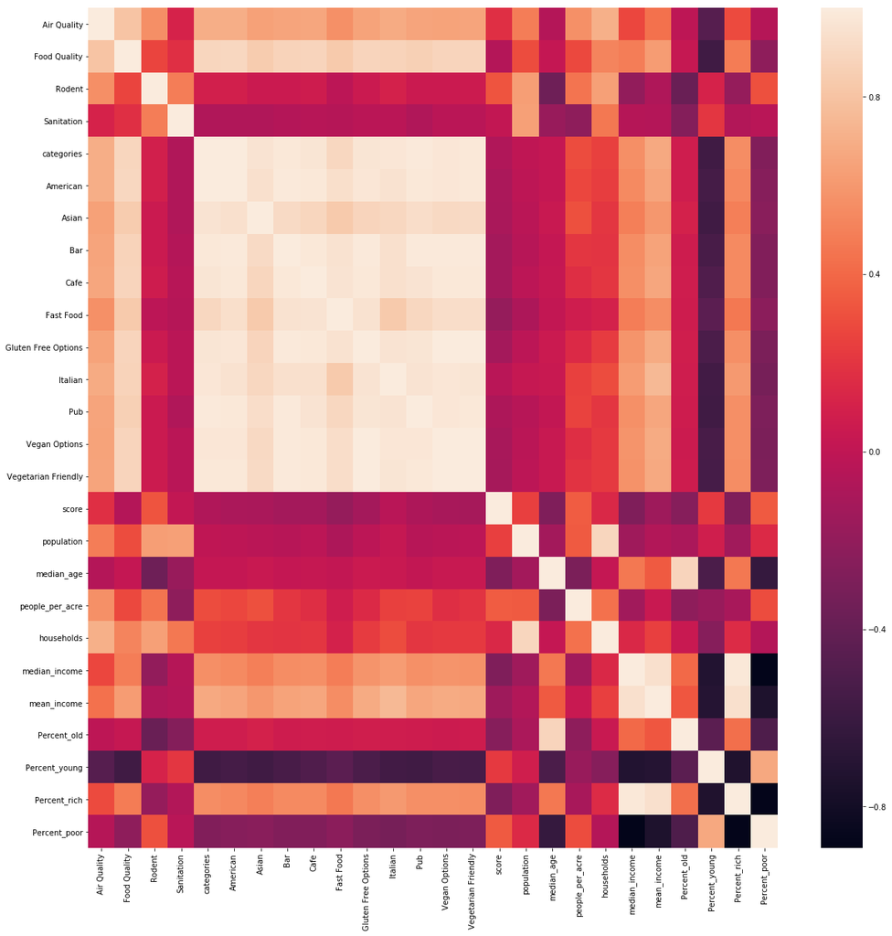

```python
# import pandas.rpy.common as com
import seaborn as sns
%matplotlib inline


# calculate the correlation matrix
corr =data.drop('constant',axis=1).corr()

# plot the heatmap
plt.figure(figsize=(20,20),)
sns.heatmap(corr,
        xticklabels=corr.columns,
        yticklabels=corr.columns)
```

```python
data.corr()
```

|  |  | Air Quality | Food Quality | Rodent | Sanitation | categories | American | Asian | Bar | Cafe | ... | population | median_age | people_per_acre | households | median_income | mean_income | Percent_old | Percent_young | Percent_rich | Percent_poor |
| --- | --- | --- | --- | --- | --- | --- | --- | --- | --- | --- | --- | --- | --- | --- | --- | --- | --- | --- | --- | --- | --- |
|  | 1.000000 | 0.009488 | -0.023650 | 0.288689 | 0.001017 | -0.105951 | -0.075219 | -0.184066 | -0.155965 | -0.163252 | ... | -0.074101 | -0.139897 | -0.036683 | -0.074025 | -0.356642 | -0.259206 | -0.089437 | 0.230856 | -0.315441 | 0.438342 |
| Air Quality | 0.009488 | 1.000000 | 0.805444 | 0.557438 | 0.112547 | 0.698704 | 0.699361 | 0.638058 | 0.657952 | 0.664136 | ... | 0.485920 | -0.054246 | 0.565639 | 0.708441 | 0.271767 | 0.435282 | -0.012918 | -0.466726 | 0.286208 | -0.043270 |
| Food Quality | -0.023650 | 0.805444 | 1.000000 | 0.263058 | 0.175528 | 0.893592 | 0.899382 | 0.840260 | 0.877424 | 0.886981 | ... | 0.290433 | 0.021675 | 0.278211 | 0.516968 | 0.483866 | 0.619074 | 0.027489 | -0.568441 | 0.478808 | -0.218009 |
| Rodent | 0.288689 | 0.557438 | 0.263058 | 1.000000 | 0.487033 | 0.085725 | 0.083625 | 0.050538 | 0.048226 | 0.062626 | ... | 0.629189 | -0.356186 | 0.450208 | 0.630564 | -0.202065 | -0.074572 | -0.379321 | 0.110484 | -0.189205 | 0.306574 |
| Sanitation | 0.001017 | 0.112547 | 0.175528 | 0.487033 | 1.000000 | -0.067008 | -0.071301 | -0.072036 | -0.056233 | -0.038039 | ... | 0.637210 | -0.170619 | -0.217358 | 0.464788 | -0.044301 | -0.055126 | -0.258056 | 0.206090 | -0.057521 | -0.031091 |
| categories | -0.105951 | 0.698704 | 0.893592 | 0.085725 | -0.067008 | 1.000000 | 0.994383 | 0.956753 | 0.979995 | 0.968213 | ... | 0.001419 | 0.021442 | 0.293477 | 0.250183 | 0.560780 | 0.679647 | 0.072701 | -0.570300 | 0.552028 | -0.272295 |
| American | -0.075219 | 0.699361 | 0.899382 | 0.083625 | -0.071301 | 0.994383 | 1.000000 | 0.942897 | 0.986602 | 0.980769 | ... | -0.005579 | 0.016794 | 0.271512 | 0.233453 | 0.540857 | 0.656421 | 0.071108 | -0.547811 | 0.531029 | -0.253441 |
| Asian | -0.184066 | 0.638058 | 0.840260 | 0.050538 | -0.072036 | 0.956753 | 0.942897 | 1.000000 | 0.915867 | 0.895799 | ... | -0.024073 | 0.045587 | 0.305760 | 0.202935 | 0.493703 | 0.599678 | 0.098686 | -0.568128 | 0.494168 | -0.238273 |
| Bar | -0.155965 | 0.657952 | 0.877424 | 0.048226 | -0.056233 | 0.979995 | 0.986602 | 0.915867 | 1.000000 | 0.984197 | ... | -0.036977 | 0.018444 | 0.203748 | 0.195997 | 0.555028 | 0.645121 | 0.063968 | -0.536365 | 0.538488 | -0.277949 |
| Cafe | -0.163252 | 0.664136 | 0.886981 | 0.062626 | -0.038039 | 0.968213 | 0.980769 | 0.895799 | 0.984197 | 1.000000 | ... | -0.015299 | 0.026829 | 0.165056 | 0.206366 | 0.560859 | 0.666331 | 0.071502 | -0.497436 | 0.538402 | -0.273150 |
| Fast Food | -0.153399 | 0.568764 | 0.832768 | -0.014013 | -0.047729 | 0.899431 | 0.934189 | 0.834861 | 0.950636 | 0.958164 | ... | -0.081761 | 0.015070 | 0.069007 | 0.101843 | 0.484717 | 0.554022 | 0.067844 | -0.443081 | 0.460591 | -0.229872 |
| Gluten Free Options | -0.165849 | 0.650269 | 0.885041 | 0.049940 | -0.024959 | 0.965461 | 0.973054 | 0.883207 | 0.985242 | 0.984955 | ... | -0.014285 | 0.047218 | 0.146295 | 0.225516 | 0.585040 | 0.686824 | 0.077870 | -0.522581 | 0.561603 | -0.300351 |
| Italian | -0.132963 | 0.683377 | 0.874709 | 0.099670 | -0.026477 | 0.972252 | 0.954066 | 0.898207 | 0.944817 | 0.945280 | ... | 0.030710 | 0.039129 | 0.252613 | 0.293752 | 0.622052 | 0.754617 | 0.070066 | -0.560600 | 0.603881 | -0.321356 |
| Pub | -0.137599 | 0.654247 | 0.861875 | 0.047957 | -0.066546 | 0.985392 | 0.978457 | 0.930803 | 0.988344 | 0.957480 | ... | -0.041105 | 0.016519 | 0.254069 | 0.202861 | 0.570051 | 0.666338 | 0.063142 | -0.569137 | 0.556458 | -0.291149 |
| Vegan Options | -0.162486 | 0.649697 | 0.887068 | 0.051973 | -0.022061 | 0.976838 | 0.977132 | 0.906496 | 0.985787 | 0.980971 | ... | -0.023661 | 0.035172 | 0.166895 | 0.217883 | 0.581726 | 0.687668 | 0.058416 | -0.536300 | 0.562359 | -0.297065 |
| Vegetarian Friendly | -0.159167 | 0.659644 | 0.887915 | 0.058860 | -0.032878 | 0.982189 | 0.983152 | 0.915812 | 0.992362 | 0.984190 | ... | -0.019414 | 0.032981 | 0.186823 | 0.222005 | 0.572904 | 0.677070 | 0.064503 | -0.539365 | 0.556095 | -0.289203 |
| score | 0.185982 | 0.175526 | -0.052915 | 0.323854 | 0.014582 | -0.071985 | -0.087448 | -0.096497 | -0.122366 | -0.120893 | ... | 0.241281 | -0.286130 | 0.350982 | 0.140596 | -0.282705 | -0.152483 | -0.251644 | 0.223585 | -0.285999 | 0.348588 |
| constant | NaN | NaN | NaN | NaN | NaN | NaN | NaN | NaN | NaN | NaN | ... | NaN | NaN | NaN | NaN | NaN | NaN | NaN | NaN | NaN | NaN |
| population | -0.074101 | 0.485920 | 0.290433 | 0.629189 | 0.637210 | 0.001419 | -0.005579 | -0.024073 | -0.036977 | -0.015299 | ... | 1.000000 | -0.126178 | 0.344057 | 0.895058 | -0.145687 | -0.057340 | -0.088426 | 0.079919 | -0.135486 | 0.148805 |
| median_age | -0.139897 | -0.054246 | 0.021675 | -0.356186 | -0.170619 | 0.021442 | 0.016794 | 0.045587 | 0.018444 | 0.026829 | ... | -0.126178 | 1.000000 | -0.296369 | 0.022556 | 0.465199 | 0.346407 | 0.886877 | -0.517018 | 0.464895 | -0.622476 |
| people_per_acre | -0.036683 | 0.565639 | 0.278211 | 0.450208 | -0.217358 | 0.293477 | 0.271512 | 0.305760 | 0.203748 | 0.165056 | ... | 0.344057 | -0.296369 | 1.000000 | 0.434161 | -0.133371 | 0.039101 | -0.216337 | -0.169229 | -0.108456 | 0.293212 |
| households | -0.074025 | 0.708441 | 0.516968 | 0.630564 | 0.464788 | 0.250183 | 0.233453 | 0.202935 | 0.195997 | 0.206366 | ... | 0.895058 | 0.022556 | 0.434161 | 1.000000 | 0.135418 | 0.243715 | 0.043186 | -0.253395 | 0.156501 | -0.055055 |
| median_income | -0.356642 | 0.271767 | 0.483866 | -0.202065 | -0.044301 | 0.560780 | 0.540857 | 0.493703 | 0.555028 | 0.560859 | ... | -0.145687 | 0.465199 | -0.133371 | 0.135418 | 1.000000 | 0.947534 | 0.405863 | -0.720381 | 0.983931 | -0.892781 |
| mean_income | -0.259206 | 0.435282 | 0.619074 | -0.074572 | -0.055126 | 0.679647 | 0.656421 | 0.599678 | 0.645121 | 0.666331 | ... | -0.057340 | 0.346407 | 0.039101 | 0.243715 | 0.947534 | 1.000000 | 0.327585 | -0.703773 | 0.943205 | -0.743607 |
| Percent_old | -0.089437 | -0.012918 | 0.027489 | -0.379321 | -0.258056 | 0.072701 | 0.071108 | 0.098686 | 0.063968 | 0.071502 | ... | -0.088426 | 0.886877 | -0.216337 | 0.043186 | 0.405863 | 0.327585 | 1.000000 | -0.442114 | 0.428247 | -0.506943 |
| Percent_young | 0.230856 | -0.466726 | -0.568441 | 0.110484 | 0.206090 | -0.570300 | -0.547811 | -0.568128 | -0.536365 | -0.497436 | ... | 0.079919 | -0.517018 | -0.169229 | -0.253395 | -0.720381 | -0.703773 | -0.442114 | 1.000000 | -0.736396 | 0.674414 |
| Percent_rich | -0.315441 | 0.286208 | 0.478808 | -0.189205 | -0.057521 | 0.552028 | 0.531029 | 0.494168 | 0.538488 | 0.538402 | ... | -0.135486 | 0.464895 | -0.108456 | 0.156501 | 0.983931 | 0.943205 | 0.428247 | -0.736396 | 1.000000 | -0.881423 |
| Percent_poor | 0.438342 | -0.043270 | -0.218009 | 0.306574 | -0.031091 | -0.272295 | -0.253441 | -0.238273 | -0.277949 | -0.273150 | ... | 0.148805 | -0.622476 | 0.293212 | -0.055055 | -0.892781 | -0.743607 | -0.506943 | 0.674414 | -0.881423 | 1.000000 |

28 rows × 28 columns

```python
y_category=pd.pivot_table(y,index='nta_code',columns='complaint_category',values='created_date',aggfunc='count')
```

```python
data=y_category.merge(total,left_index=True,right_index=True)
```

```python
data['constant']=1
```

```python
demographics
```

|  | nta_name | borough | nta_code | population | under_5_years | 5-9_years | 10-14_years | 15-19_years | 20-24_years | 25-29_years | ... | 75000_to_99999 | 100000_to_149999 | 150000_to_199999 | 200000_or_more | median_income | mean_income | Percent_old | Percent_young | Percent_rich | Percent_poor |
| --- | --- | --- | --- | --- | --- | --- | --- | --- | --- | --- | --- | --- | --- | --- | --- | --- | --- | --- | --- | --- | --- |
| 0 | Allerton-Pelham Gardens | Bronx | BX31 | 28903 | 1679 | 1706 | 1763 | 2039 | 1964 | 1703 | ... | 0.120476 | 0.162929 | 0.079796 | 0.044539 | 61638 | 78489 | 0.229907 | 0.248659 | 0.287264 | 0.287264 |
| 1 | Annadale-Huguenot-Prince's Bay-Eltingville | Staten Island | SI01 | 27770 | 1397 | 1698 | 1817 | 1880 | 1720 | 1594 | ... | 0.136166 | 0.209914 | 0.109863 | 0.116439 | 88288 | 109187 | 0.209183 | 0.244580 | 0.436216 | 0.171573 |
| 2 | Arden Heights | Staten Island | SI48 | 25238 | 1507 | 1540 | 1596 | 1752 | 1614 | 1561 | ... | 0.179799 | 0.225558 | 0.116853 | 0.082589 | 89570 | 101627 | 0.176440 | 0.253388 | 0.425000 | 0.157701 |
| 3 | Astoria | Queens | QN70 | 78793 | 3480 | 3037 | 3060 | 3392 | 6630 | 11586 | ... | 0.132818 | 0.136928 | 0.047421 | 0.034888 | 54882 | 70094 | 0.156346 | 0.164596 | 0.219236 | 0.321860 |
| 4 | Auburndale | Queens | QN48 | 19996 | 917 | 966 | 1063 | 1168 | 1214 | 1307 | ... | 0.148835 | 0.173687 | 0.082701 | 0.060798 | 70772 | 84402 | 0.225145 | 0.205741 | 0.317186 | 0.238135 |
| 5 | Baisley Park | Queens | QN76 | 34603 | 2198 | 2389 | 2569 | 2923 | 2699 | 2430 | ... | 0.142777 | 0.160112 | 0.058621 | 0.028611 | 59357 | 72664 | 0.149265 | 0.291275 | 0.247344 | 0.259366 |
| 6 | Bath Beach | Brooklyn | BK27 | 29931 | 1766 | 1668 | 1672 | 1581 | 1922 | 2234 | ... | 0.105708 | 0.144360 | 0.063910 | 0.046831 | 55193 | 76037 | 0.214694 | 0.223414 | 0.255101 | 0.331506 |
| 7 | Battery Park City-Lower Manhattan | Manhattan | MN25 | 39699 | 2272 | 1055 | 691 | 1453 | 5203 | 7559 | ... | 0.113876 | 0.182787 | 0.112038 | 0.313443 | 125434 | 185275 | 0.088844 | 0.137812 | 0.608267 | 0.142628 |
| 8 | Bay Ridge | Brooklyn | BK31 | 78607 | 4571 | 3998 | 3772 | 3802 | 4700 | 7214 | ... | 0.118716 | 0.139150 | 0.071390 | 0.068761 | 57980 | 82209 | 0.198939 | 0.205363 | 0.279300 | 0.318939 |
| 9 | Bayside-Bayside Hills | Queens | QN46 | 43808 | 2106 | 2199 | 2353 | 2694 | 2504 | 2832 | ... | 0.147426 | 0.190342 | 0.106822 | 0.079710 | 79120 | 94806 | 0.221786 | 0.213477 | 0.376874 | 0.214205 |
| 10 | Bedford | Brooklyn | BK75 | 70713 | 6850 | 6109 | 5426 | 5390 | 6377 | 7007 | ... | 0.083427 | 0.098194 | 0.042335 | 0.022512 | 37343 | 55606 | 0.109287 | 0.336218 | 0.163042 | 0.477929 |
| 11 | Bedford Park-Fordham North | Bronx | BX05 | 54415 | 4517 | 4183 | 4058 | 4623 | 4693 | 4663 | ... | 0.084943 | 0.057791 | 0.007995 | 0.007995 | 29549 | 41324 | 0.105339 | 0.319416 | 0.073782 | 0.564445 |
| 12 | Bellerose | Queens | QN43 | 25287 | 1347 | 1374 | 1485 | 1659 | 1674 | 1726 | ... | 0.156568 | 0.194862 | 0.104217 | 0.062288 | 77863 | 91677 | 0.192866 | 0.231937 | 0.361367 | 0.199588 |
| 13 | Belmont | Bronx | BX06 | 27378 | 2076 | 2073 | 1969 | 3458 | 3937 | 2157 | ... | 0.042346 | 0.038065 | 0.010413 | 0.001620 | 21924 | 31783 | 0.098765 | 0.349770 | 0.050098 | 0.700914 |
| 14 | Bensonhurst East | Brooklyn | BK29 | 62978 | 3578 | 3377 | 3360 | 3528 | 4381 | 4924 | ... | 0.111541 | 0.108264 | 0.040366 | 0.028943 | 45108 | 63848 | 0.204309 | 0.219807 | 0.177573 | 0.394830 |
| 15 | Bensonhurst West | Brooklyn | BK28 | 88727 | 5104 | 4905 | 5038 | 5405 | 6731 | 6877 | ... | 0.109268 | 0.116429 | 0.040663 | 0.027442 | 46137 | 63192 | 0.197482 | 0.230505 | 0.184534 | 0.383655 |
| 16 | Borough Park | Brooklyn | BK88 | 106357 | 14703 | 11971 | 10024 | 9094 | 8640 | 7872 | ... | 0.075933 | 0.088375 | 0.037078 | 0.027835 | 35754 | 55689 | 0.132845 | 0.430550 | 0.153288 | 0.493175 |
| 17 | Breezy Point-Belle Harbor-Rockaway Park-Broad ... | Queens | QN10 | 28018 | 1454 | 1595 | 1574 | 1684 | 1385 | 1473 | ... | 0.156267 | 0.178723 | 0.086692 | 0.076569 | 74718 | 93505 | 0.248233 | 0.225105 | 0.341984 | 0.247193 |
| 18 | Briarwood-Jamaica Hills | Queens | QN35 | 39138 | 2418 | 2049 | 1992 | 2367 | 2947 | 3337 | ... | 0.111103 | 0.165126 | 0.059774 | 0.024390 | 58564 | 71223 | 0.178113 | 0.225510 | 0.249290 | 0.293775 |
| 19 | Brighton Beach | Brooklyn | BK19 | 35547 | 1780 | 1526 | 1514 | 1728 | 2221 | 2393 | ... | 0.078756 | 0.086815 | 0.043408 | 0.047013 | 30872 | 59875 | 0.301938 | 0.184207 | 0.177236 | 0.532556 |
| 20 | Bronxdale | Bronx | BX07 | 35538 | 2458 | 2311 | 2404 | 2600 | 2629 | 2953 | ... | 0.120874 | 0.076192 | 0.017813 | 0.004191 | 36859 | 47292 | 0.163121 | 0.275001 | 0.098196 | 0.480204 |
| 21 | Brooklyn Heights-Cobble Hill | Brooklyn | BK09 | 22887 | 1300 | 695 | 499 | 941 | 1628 | 2519 | ... | 0.107557 | 0.162287 | 0.106289 | 0.251540 | 105398 | 169555 | 0.187093 | 0.150085 | 0.520116 | 0.192461 |
| 22 | Brownsville | Brooklyn | BK81 | 58300 | 4490 | 4569 | 5049 | 5864 | 4963 | 4019 | ... | 0.067665 | 0.038897 | 0.012268 | 0.006942 | 25041 | 36810 | 0.136123 | 0.342573 | 0.058107 | 0.625630 |
| 23 | Bushwick North | Brooklyn | BK77 | 57138 | 4304 | 3894 | 3637 | 4177 | 6247 | 6884 | ... | 0.100464 | 0.098432 | 0.032515 | 0.016570 | 42296 | 56593 | 0.094421 | 0.280234 | 0.147517 | 0.427753 |
| 24 | Bushwick South | Brooklyn | BK78 | 72101 | 4838 | 4712 | 5004 | 5619 | 7712 | 8016 | ... | 0.094545 | 0.084888 | 0.026197 | 0.011300 | 37285 | 49696 | 0.127099 | 0.279788 | 0.122385 | 0.476989 |
| 25 | Cambria Heights | Queens | QN33 | 18677 | 907 | 977 | 1064 | 1291 | 1225 | 1081 | ... | 0.124150 | 0.234866 | 0.107316 | 0.057948 | 79888 | 93955 | 0.239225 | 0.226964 | 0.400129 | 0.180803 |
| 26 | Canarsie | Brooklyn | BK50 | 83693 | 5027 | 5369 | 5909 | 6838 | 6425 | 5766 | ... | 0.149712 | 0.150174 | 0.068032 | 0.033838 | 60766 | 73367 | 0.156130 | 0.276523 | 0.252044 | 0.292564 |
| 27 | Carroll Gardens-Columbia Street-Red Hook | Brooklyn | BK33 | 38353 | 2748 | 1942 | 1620 | 1577 | 1885 | 3986 | ... | 0.098954 | 0.163893 | 0.105476 | 0.173226 | 85496 | 124522 | 0.142831 | 0.205642 | 0.442595 | 0.260767 |
| 28 | Central Harlem North-Polo Grounds | Manhattan | MN03 | 75282 | 4762 | 4478 | 4658 | 5569 | 6248 | 6490 | ... | 0.080098 | 0.063105 | 0.023808 | 0.033426 | 34413 | 52748 | 0.152879 | 0.258588 | 0.120339 | 0.507405 |
| 29 | Central Harlem South | Manhattan | MN11 | 43383 | 2686 | 2449 | 2391 | 2622 | 3416 | 4197 | ... | 0.078739 | 0.122852 | 0.061558 | 0.072626 | 48366 | 78612 | 0.128737 | 0.233917 | 0.257036 | 0.400601 |
| ... | ... | ... | ... | ... | ... | ... | ... | ... | ... | ... | ... | ... | ... | ... | ... | ... | ... | ... | ... | ... | ... |
| 158 | Starrett City | Brooklyn | BK93 | 13354 | 634 | 656 | 795 | 910 | 844 | 736 | ... | 0.053148 | 0.031794 | 0.004429 | 0.009174 | 27397 | 38040 | 0.316759 | 0.224277 | 0.045397 | 0.554413 |
| 159 | Steinway | Queens | QN72 | 47534 | 2249 | 1833 | 1773 | 1849 | 3529 | 6395 | ... | 0.121740 | 0.162972 | 0.064506 | 0.038824 | 60618 | 75776 | 0.182185 | 0.162073 | 0.266302 | 0.277739 |
| 160 | Stuyvesant Heights | Brooklyn | BK35 | 63504 | 4290 | 4158 | 4424 | 4987 | 5316 | 5466 | ... | 0.095388 | 0.099738 | 0.033716 | 0.027754 | 37082 | 54363 | 0.139535 | 0.281226 | 0.161208 | 0.483061 |
| 161 | Stuyvesant Town-Cooper Village | Manhattan | MN50 | 21049 | 794 | 557 | 493 | 449 | 2856 | 3138 | ... | 0.164010 | 0.207317 | 0.107259 | 0.152775 | 95022 | 113165 | 0.238301 | 0.108936 | 0.467352 | 0.211638 |
| 162 | Sunset Park East | Brooklyn | BK34 | 72340 | 5949 | 5172 | 4362 | 4832 | 6323 | 7374 | ... | 0.094924 | 0.060177 | 0.023756 | 0.011188 | 35636 | 47759 | 0.116381 | 0.280827 | 0.095121 | 0.492016 |
| 163 | Sunset Park West | Brooklyn | BK32 | 54041 | 3841 | 3381 | 3054 | 3531 | 5003 | 6214 | ... | 0.095826 | 0.118105 | 0.032281 | 0.033299 | 44165 | 61435 | 0.118725 | 0.255491 | 0.183686 | 0.409714 |
| 164 | Todt Hill-Emerson Hill-Heartland Village-Light... | Staten Island | SI24 | 30714 | 1498 | 1595 | 1818 | 1962 | 1821 | 1802 | ... | 0.123628 | 0.207611 | 0.102832 | 0.094425 | 80761 | 109101 | 0.246109 | 0.223774 | 0.404867 | 0.199115 |
| 165 | Turtle Bay-East Midtown | Manhattan | MN19 | 51231 | 1849 | 1076 | 761 | 993 | 3523 | 6966 | ... | 0.115321 | 0.179756 | 0.092015 | 0.281183 | 113998 | 196721 | 0.265640 | 0.091331 | 0.552955 | 0.155382 |
| 166 | University Heights-Morris Heights | Bronx | BX36 | 54188 | 4350 | 4300 | 4348 | 5154 | 4757 | 4164 | ... | 0.056565 | 0.030713 | 0.009004 | 0.000884 | 25073 | 33652 | 0.108327 | 0.334982 | 0.040601 | 0.635199 |
| 167 | Upper East Side-Carnegie Hill | Manhattan | MN40 | 61207 | 3174 | 3136 | 3003 | 2277 | 2339 | 3690 | ... | 0.088676 | 0.141799 | 0.094242 | 0.415585 | 155213 | 311109 | 0.321859 | 0.189357 | 0.651626 | 0.125691 |
| 168 | Upper West Side | Manhattan | MN12 | 132378 | 7197 | 5482 | 4817 | 4338 | 6600 | 11971 | ... | 0.091890 | 0.149845 | 0.095650 | 0.226091 | 92268 | 161302 | 0.240614 | 0.164937 | 0.471586 | 0.238305 |
| 169 | Van Cortlandt Village | Bronx | BX28 | 50100 | 3583 | 3176 | 3315 | 3987 | 4029 | 3991 | ... | 0.110548 | 0.073507 | 0.024829 | 0.006855 | 40669 | 50900 | 0.152355 | 0.280659 | 0.105190 | 0.438044 |
| 170 | Van Nest-Morris Park-Westchester Square | Bronx | BX37 | 29250 | 2057 | 2072 | 2092 | 2204 | 2141 | 2242 | ... | 0.099418 | 0.129857 | 0.025452 | 0.014232 | 44588 | 57782 | 0.153231 | 0.288034 | 0.169541 | 0.400374 |
| 171 | Washington Heights North | Manhattan | MN35 | 67136 | 3875 | 3278 | 3411 | 4208 | 6501 | 5997 | ... | 0.129099 | 0.114672 | 0.035911 | 0.045424 | 50192 | 67541 | 0.180529 | 0.220031 | 0.196007 | 0.379616 |
| 172 | Washington Heights South | Manhattan | MN36 | 84438 | 4501 | 4022 | 4486 | 5888 | 8377 | 8417 | ... | 0.092325 | 0.076409 | 0.020876 | 0.025079 | 36518 | 52338 | 0.172896 | 0.223797 | 0.122365 | 0.485221 |
| 173 | West Brighton | Brooklyn | BK23 | 17750 | 506 | 485 | 507 | 575 | 798 | 863 | ... | 0.077501 | 0.099803 | 0.050394 | 0.013677 | 38047 | 53608 | 0.429915 | 0.116789 | 0.163874 | 0.463036 |
| 174 | West Concourse | Bronx | BX63 | 39282 | 3357 | 3070 | 3043 | 3384 | 3369 | 3082 | ... | 0.054750 | 0.041043 | 0.009508 | 0.001347 | 27637 | 36440 | 0.110967 | 0.327224 | 0.051898 | 0.604786 |
| 175 | West Farms-Bronx River | Bronx | BX08 | 35011 | 2751 | 2635 | 2561 | 3049 | 2954 | 2883 | ... | 0.082655 | 0.079315 | 0.016617 | 0.011049 | 29382 | 44247 | 0.133501 | 0.314073 | 0.106981 | 0.558972 |
| 176 | West New Brighton-New Brighton-St. George | Staten Island | SI22 | 33551 | 2491 | 2523 | 2407 | 2732 | 2470 | 2405 | ... | 0.124197 | 0.129354 | 0.058083 | 0.032973 | 48439 | 64533 | 0.139728 | 0.302614 | 0.220409 | 0.407508 |
| 177 | West Village | Manhattan | MN23 | 66880 | 2219 | 1568 | 1054 | 3795 | 5313 | 9747 | ... | 0.104332 | 0.157310 | 0.115555 | 0.271376 | 112689 | 180247 | 0.186857 | 0.129127 | 0.544241 | 0.162416 |
| 178 | Westchester-Unionport | Bronx | BX59 | 27248 | 1927 | 1907 | 2029 | 2128 | 2160 | 2092 | ... | 0.119211 | 0.102535 | 0.022535 | 0.025352 | 45536 | 56201 | 0.147681 | 0.293269 | 0.150423 | 0.419268 |
| 179 | Westerleigh | Staten Island | SI07 | 24102 | 1390 | 1436 | 1473 | 1520 | 1340 | 1438 | ... | 0.144166 | 0.221374 | 0.098691 | 0.076881 | 82128 | 96344 | 0.217202 | 0.241432 | 0.396947 | 0.203053 |
| 180 | Whitestone | Queens | QN49 | 30773 | 1554 | 1564 | 1682 | 1627 | 1580 | 1710 | ... | 0.123344 | 0.232218 | 0.088999 | 0.082810 | 80546 | 99025 | 0.268190 | 0.208852 | 0.404027 | 0.215743 |
| 181 | Williamsbridge-Olinville | Bronx | BX44 | 61321 | 4539 | 4593 | 4532 | 5083 | 4598 | 4363 | ... | 0.099590 | 0.089162 | 0.022061 | 0.010572 | 39178 | 49987 | 0.153846 | 0.305719 | 0.121796 | 0.456819 |
| 182 | Williamsburg | Brooklyn | BK72 | 32926 | 5637 | 4081 | 3517 | 3404 | 3019 | 2397 | ... | 0.047430 | 0.037464 | 0.005764 | 0.016691 | 21502 | 36448 | 0.100559 | 0.505345 | 0.059918 | 0.682997 |
| 183 | Windsor Terrace | Brooklyn | BK40 | 20988 | 1447 | 1054 | 878 | 759 | 1105 | 1971 | ... | 0.141805 | 0.210948 | 0.078212 | 0.110435 | 82297 | 102796 | 0.168477 | 0.197160 | 0.399595 | 0.230901 |
| 184 | Woodhaven | Queens | QN53 | 56674 | 3641 | 3642 | 3983 | 4395 | 4584 | 4392 | ... | 0.139593 | 0.146477 | 0.064561 | 0.049578 | 61804 | 77846 | 0.136606 | 0.276335 | 0.260616 | 0.281731 |
| 185 | Woodlawn-Wakefield | Bronx | BX62 | 42483 | 2562 | 2550 | 2833 | 3046 | 3054 | 3338 | ... | 0.152600 | 0.138267 | 0.054600 | 0.023467 | 55443 | 67014 | 0.178589 | 0.258715 | 0.216333 | 0.331133 |
| 186 | Woodside | Queens | QN63 | 45099 | 2415 | 2265 | 2105 | 2274 | 3328 | 4488 | ... | 0.124547 | 0.130981 | 0.039975 | 0.029919 | 50952 | 66068 | 0.167786 | 0.200869 | 0.200874 | 0.323735 |
| 187 | Yorkville | Manhattan | MN32 | 77942 | 3751 | 2633 | 2152 | 1849 | 5375 | 11411 | ... | 0.118440 | 0.173157 | 0.093390 | 0.227965 | 98840 | 151203 | 0.199648 | 0.133240 | 0.494512 | 0.192754 |

188 rows × 37 columns

```python
data.columns
```

```
Index([' ', 'Air Quality', 'Food Quality', 'Rodent', 'Sanitation',
       'categories', 'American', 'Asian', 'Bar', 'Cafe', 'Fast Food',
       'Gluten Free Options', 'Italian', 'Pub', 'Vegan Options',
       'Vegetarian Friendly', 'score'],
      dtype='object')
```

```python
# reg1 = sm.OLS(endog=data['Food Quality']/data['categories'], exog=data[[ 'American', 'Asian', 'Bar', 'Cafe', 'Fast Food',
#        'Gluten Free Options', 'Italian', 'Pub', 'Vegan Options',
#        'Vegetarian Friendly', 'score','constant']], missing='drop')
reg1 = sm.OLS(endog=data['Sanitation'], exog=data[[ 'score','constant']], missing='drop')
```

```python
model=reg1.fit()
```

```python
model.summary()
```

OLS Regression Results

| Dep. Variable: | Sanitation | R-squared: | 0.000 |
| --- | --- | --- | --- |
| Model: | OLS | Adj. R-squared: | -0.014 |
| Method: | Least Squares | F-statistic: | 0.01510 |
| Date: | Sat, 22 Sep 2018 | Prob (F-statistic): | 0.903 |
| Time: | 13:54:29 | Log-Likelihood: | -653.69 |
| No. Observations: | 73 | AIC: | 1311. |
| Df Residuals: | 71 | BIC: | 1316. |
| Df Model: | 1 |  |  |
| Covariance Type: | nonrobust |  |  |

|  | coef | std err | t | P>\|t\| | [0.025 | 0.975] |
| --- | --- | --- | --- | --- | --- | --- |
| score | 21.6528 | 176.205 | 0.123 | 0.903 | -329.689 | 372.995 |
| constant | 2908.4956 | 3377.670 | 0.861 | 0.392 | -3826.388 | 9643.379 |

| Omnibus: | 11.541 | Durbin-Watson: | 1.618 |
| --- | --- | --- | --- |
| Prob(Omnibus): | 0.003 | Jarque-Bera (JB): | 12.013 |
| Skew: | 0.964 | Prob(JB): | 0.00246 |
| Kurtosis: | 3.482 | Cond. No. | 292. |

Warnings:  
[1] Standard Errors assume that the covariance matrix of the errors is correctly specified.

```python
data
```

|  |  | Air Quality | Food Quality | Rodent | Sanitation | categories | American | Asian | Bar | Cafe | Fast Food | Gluten Free Options | Italian | Pub | Vegan Options | Vegetarian Friendly | score | constant |
| --- | --- | --- | --- | --- | --- | --- | --- | --- | --- | --- | --- | --- | --- | --- | --- | --- | --- | --- |
| BK09 | NaN | 211.0 | 394.0 | 374.0 | 708.0 | 1.0 | 1.0 | 0.0 | 1.0 | 0.0 | 0.0 | 0.0 | 0.0 | 1.0 | 0.0 | 0.0 | 18.664939 | 1 |
| BK17 | NaN | 491.0 | 687.0 | 1024.0 | 4692.0 | 1.0 | 0.0 | 0.0 | 0.0 | 0.0 | 0.0 | 1.0 | 1.0 | 0.0 | 1.0 | 1.0 | 18.745070 | 1 |
| BK25 | NaN | 304.0 | 392.0 | 562.0 | 3762.0 | 1.0 | 1.0 | 0.0 | 0.0 | 0.0 | 0.0 | 0.0 | 0.0 | 0.0 | 0.0 | 0.0 | 18.867841 | 1 |
| BK30 | NaN | 128.0 | 275.0 | 606.0 | 2634.0 | 1.0 | 1.0 | 0.0 | 0.0 | 0.0 | 0.0 | 0.0 | 0.0 | 0.0 | 0.0 | 0.0 | 19.464467 | 1 |
| BK31 | NaN | 721.0 | 1121.0 | 1104.0 | 4932.0 | 2.0 | 0.0 | 0.0 | 0.0 | 0.0 | 0.0 | 0.0 | 1.0 | 0.0 | 0.0 | 0.0 | 19.615694 | 1 |
| BK32 | NaN | 288.0 | 497.0 | 849.0 | 3286.0 | 5.0 | 4.0 | 0.0 | 0.0 | 0.0 | 0.0 | 0.0 | 0.0 | 0.0 | 0.0 | 1.0 | 20.408220 | 1 |
| BK33 | NaN | 265.0 | 545.0 | 937.0 | 3534.0 | 6.0 | 3.0 | 0.0 | 1.0 | 0.0 | 0.0 | 0.0 | 0.0 | 1.0 | 1.0 | 1.0 | 18.560061 | 1 |
| BK35 | 11.0 | 694.0 | 612.0 | 4054.0 | 5711.0 | 2.0 | 1.0 | 0.0 | 0.0 | 0.0 | 0.0 | 0.0 | 1.0 | 0.0 | 0.0 | 0.0 | 19.853061 | 1 |
| BK37 | NaN | 559.0 | 1131.0 | 2869.0 | 5768.0 | 13.0 | 7.0 | 1.0 | 2.0 | 0.0 | 0.0 | 0.0 | 1.0 | 2.0 | 0.0 | 0.0 | 18.683593 | 1 |
| BK45 | NaN | 142.0 | 368.0 | 668.0 | 3704.0 | 5.0 | 3.0 | 0.0 | 0.0 | 1.0 | 0.0 | 0.0 | 0.0 | 0.0 | 0.0 | 1.0 | 18.284066 | 1 |
| BK60 | 10.0 | 606.0 | 528.0 | 2451.0 | 3658.0 | 1.0 | 0.0 | 0.0 | 0.0 | 0.0 | 0.0 | 0.0 | 1.0 | 0.0 | 0.0 | 0.0 | 20.489268 | 1 |
| BK61 | NaN | 963.0 | 1267.0 | 5524.0 | 8270.0 | 1.0 | 1.0 | 0.0 | 0.0 | 0.0 | 0.0 | 0.0 | 0.0 | 0.0 | 0.0 | 0.0 | 20.201484 | 1 |
| BK68 | NaN | 195.0 | 422.0 | 1133.0 | 1495.0 | 1.0 | 0.0 | 0.0 | 0.0 | 0.0 | 0.0 | 0.0 | 1.0 | 0.0 | 0.0 | 0.0 | 18.326337 | 1 |
| BK73 | NaN | 515.0 | 874.0 | 1701.0 | 3798.0 | 13.0 | 7.0 | 2.0 | 1.0 | 1.0 | 0.0 | 1.0 | 0.0 | 1.0 | 1.0 | 0.0 | 17.797818 | 1 |
| BK76 | NaN | 347.0 | 554.0 | 1435.0 | 2705.0 | 5.0 | 4.0 | 0.0 | 0.0 | 0.0 | 0.0 | 0.0 | 0.0 | 0.0 | 0.0 | 0.0 | 19.025549 | 1 |
| BK77 | 1.0 | 453.0 | 519.0 | 2799.0 | 3683.0 | 2.0 | 2.0 | 0.0 | 0.0 | 0.0 | 0.0 | 0.0 | 0.0 | 0.0 | 0.0 | 0.0 | 22.428932 | 1 |
| BK78 | NaN | 414.0 | 500.0 | 3998.0 | 5662.0 | 4.0 | 3.0 | 0.0 | 0.0 | 0.0 | 0.0 | 0.0 | 0.0 | 0.0 | 0.0 | 0.0 | 19.719424 | 1 |
| BK81 | NaN | 297.0 | 500.0 | 1473.0 | 2742.0 | 1.0 | 1.0 | 0.0 | 0.0 | 0.0 | 0.0 | 0.0 | 0.0 | 0.0 | 0.0 | 0.0 | 19.999381 | 1 |
| BK82 | 5.0 | 359.0 | 853.0 | 3059.0 | 9098.0 | 1.0 | 1.0 | 0.0 | 0.0 | 0.0 | 0.0 | 0.0 | 0.0 | 0.0 | 0.0 | 0.0 | 20.015617 | 1 |
| BK88 | 1.0 | 289.0 | 388.0 | 1076.0 | 6311.0 | 2.0 | 0.0 | 0.0 | 0.0 | 0.0 | 0.0 | 0.0 | 1.0 | 0.0 | 0.0 | 0.0 | 20.507860 | 1 |
| BX06 | 3.0 | 230.0 | 393.0 | 1211.0 | 1015.0 | 5.0 | 1.0 | 0.0 | 0.0 | 1.0 | 0.0 | 0.0 | 3.0 | 0.0 | 0.0 | 0.0 | 20.678768 | 1 |
| BX22 | NaN | 132.0 | 157.0 | 405.0 | 960.0 | 2.0 | 2.0 | 0.0 | 0.0 | 0.0 | 0.0 | 0.0 | 0.0 | 0.0 | 0.0 | 0.0 | 18.450075 | 1 |
| BX26 | NaN | 223.0 | 165.0 | 1295.0 | 1394.0 | 2.0 | 0.0 | 1.0 | 0.0 | 0.0 | 1.0 | 0.0 | 0.0 | 0.0 | 0.0 | 1.0 | 20.655907 | 1 |
| BX27 | NaN | 222.0 | 274.0 | 1213.0 | 1923.0 | 1.0 | 1.0 | 0.0 | 0.0 | 0.0 | 0.0 | 0.0 | 0.0 | 0.0 | 0.0 | 0.0 | 18.245098 | 1 |
| BX29 | NaN | 260.0 | 442.0 | 633.0 | 1263.0 | 2.0 | 2.0 | 0.0 | 1.0 | 0.0 | 0.0 | 0.0 | 0.0 | 0.0 | 0.0 | 0.0 | 19.556865 | 1 |
| BX41 | NaN | 319.0 | 308.0 | 2052.0 | 1581.0 | 2.0 | 2.0 | 0.0 | 0.0 | 0.0 | 0.0 | 0.0 | 0.0 | 0.0 | 0.0 | 0.0 | 18.689215 | 1 |
| BX46 | 1.0 | 175.0 | 243.0 | 256.0 | 402.0 | 3.0 | 2.0 | 0.0 | 0.0 | 0.0 | 0.0 | 0.0 | 0.0 | 0.0 | 0.0 | 0.0 | 17.191841 | 1 |
| BX63 | NaN | 282.0 | 375.0 | 1227.0 | 1074.0 | 2.0 | 1.0 | 0.0 | 0.0 | 0.0 | 0.0 | 0.0 | 0.0 | 0.0 | 0.0 | 0.0 | 19.800000 | 1 |
| MN03 | 1.0 | 881.0 | 771.0 | 2949.0 | 3455.0 | 66.0 | 48.0 | 1.0 | 6.0 | 3.0 | 0.0 | 1.0 | 2.0 | 4.0 | 1.0 | 9.0 | 19.394855 | 1 |
| MN04 | NaN | 1129.0 | 384.0 | 2524.0 | 1655.0 | 83.0 | 55.0 | 2.0 | 5.0 | 5.0 | 0.0 | 1.0 | 4.0 | 4.0 | 0.0 | 5.0 | 20.875232 | 1 |
| ... | ... | ... | ... | ... | ... | ... | ... | ... | ... | ... | ... | ... | ... | ... | ... | ... | ... | ... |
| MN34 | 20.0 | 588.0 | 1219.0 | 2098.0 | 2438.0 | 119.0 | 82.0 | 0.0 | 4.0 | 1.0 | 1.0 | 0.0 | 6.0 | 4.0 | 0.0 | 4.0 | 20.314974 | 1 |
| MN35 | NaN | 1070.0 | 550.0 | 2060.0 | 2038.0 | 86.0 | 48.0 | 1.0 | 8.0 | 2.0 | 1.0 | 2.0 | 2.0 | 8.0 | 0.0 | 3.0 | 21.251335 | 1 |
| MN36 | 1.0 | 833.0 | 711.0 | 2805.0 | 2187.0 | 94.0 | 55.0 | 2.0 | 4.0 | 2.0 | 0.0 | 0.0 | 2.0 | 4.0 | 0.0 | 0.0 | 20.752548 | 1 |
| QN06 | NaN | 73.0 | 214.0 | 333.0 | 1966.0 | 1.0 | 1.0 | 0.0 | 0.0 | 0.0 | 0.0 | 0.0 | 0.0 | 0.0 | 0.0 | 0.0 | 20.318384 | 1 |
| QN07 | NaN | 76.0 | 93.0 | 447.0 | 2066.0 | 1.0 | 1.0 | 0.0 | 0.0 | 0.0 | 0.0 | 0.0 | 0.0 | 0.0 | 0.0 | 0.0 | 17.303665 | 1 |
| QN08 | 1.0 | 122.0 | 276.0 | 1724.0 | 6797.0 | 2.0 | 1.0 | 0.0 | 0.0 | 0.0 | 0.0 | 0.0 | 0.0 | 0.0 | 0.0 | 0.0 | 17.187156 | 1 |
| QN12 | NaN | 227.0 | 189.0 | 604.0 | 2055.0 | 4.0 | 4.0 | 0.0 | 0.0 | 0.0 | 0.0 | 0.0 | 0.0 | 0.0 | 0.0 | 0.0 | 17.719231 | 1 |
| QN17 | NaN | 541.0 | 951.0 | 884.0 | 4166.0 | 5.0 | 1.0 | 0.0 | 0.0 | 1.0 | 0.0 | 0.0 | 1.0 | 0.0 | 1.0 | 1.0 | 16.646131 | 1 |
| QN18 | 2.0 | 212.0 | 368.0 | 478.0 | 1180.0 | 1.0 | 1.0 | 0.0 | 1.0 | 0.0 | 0.0 | 0.0 | 0.0 | 0.0 | 0.0 | 0.0 | 17.616270 | 1 |
| QN20 | NaN | 336.0 | 639.0 | 2516.0 | 6372.0 | 3.0 | 3.0 | 0.0 | 0.0 | 0.0 | 0.0 | 0.0 | 0.0 | 0.0 | 0.0 | 0.0 | 16.987741 | 1 |
| QN21 | NaN | 88.0 | 216.0 | 700.0 | 2380.0 | 2.0 | 1.0 | 0.0 | 0.0 | 0.0 | 0.0 | 0.0 | 0.0 | 0.0 | 0.0 | 0.0 | 19.395604 | 1 |
| QN22 | 1.0 | 558.0 | 1523.0 | 591.0 | 2840.0 | 5.0 | 3.0 | 2.0 | 0.0 | 0.0 | 0.0 | 0.0 | 0.0 | 0.0 | 0.0 | 0.0 | 20.455711 | 1 |
| QN28 | 1.0 | 341.0 | 1047.0 | 1396.0 | 4850.0 | 7.0 | 4.0 | 1.0 | 0.0 | 0.0 | 0.0 | 0.0 | 0.0 | 0.0 | 0.0 | 0.0 | 19.889676 | 1 |
| QN31 | NaN | 572.0 | 1086.0 | 1296.0 | 4502.0 | 8.0 | 4.0 | 0.0 | 0.0 | 0.0 | 1.0 | 0.0 | 0.0 | 0.0 | 0.0 | 0.0 | 18.809202 | 1 |
| QN34 | NaN | 115.0 | 230.0 | 913.0 | 4516.0 | 3.0 | 3.0 | 0.0 | 0.0 | 0.0 | 0.0 | 0.0 | 0.0 | 0.0 | 0.0 | 0.0 | 19.716769 | 1 |
| QN37 | NaN | 246.0 | 260.0 | 395.0 | 2731.0 | 3.0 | 2.0 | 0.0 | 1.0 | 0.0 | 0.0 | 0.0 | 0.0 | 1.0 | 0.0 | 0.0 | 19.421555 | 1 |
| QN43 | NaN | 40.0 | 160.0 | 341.0 | 1484.0 | 2.0 | 0.0 | 1.0 | 0.0 | 0.0 | 0.0 | 0.0 | 0.0 | 0.0 | 0.0 | 0.0 | 16.745000 | 1 |
| QN45 | 2.0 | 75.0 | 188.0 | 147.0 | 1566.0 | 2.0 | 2.0 | 0.0 | 0.0 | 0.0 | 0.0 | 0.0 | 0.0 | 0.0 | 0.0 | 0.0 | 17.452023 | 1 |
| QN46 | NaN | 197.0 | 412.0 | 495.0 | 2944.0 | 1.0 | 1.0 | 0.0 | 0.0 | 0.0 | 0.0 | 0.0 | 0.0 | 0.0 | 0.0 | 0.0 | 17.132819 | 1 |
| QN50 | 4.0 | 65.0 | 255.0 | 598.0 | 1684.0 | 3.0 | 1.0 | 1.0 | 0.0 | 0.0 | 0.0 | 0.0 | 0.0 | 0.0 | 1.0 | 0.0 | 19.757320 | 1 |
| QN51 | NaN | 190.0 | 402.0 | 373.0 | 2701.0 | 2.0 | 1.0 | 0.0 | 0.0 | 0.0 | 0.0 | 0.0 | 0.0 | 0.0 | 0.0 | 0.0 | 19.256320 | 1 |
| QN53 | 1.0 | 151.0 | 341.0 | 911.0 | 5368.0 | 1.0 | 0.0 | 0.0 | 1.0 | 0.0 | 0.0 | 0.0 | 0.0 | 1.0 | 0.0 | 0.0 | 20.161404 | 1 |
| QN54 | NaN | 212.0 | 566.0 | 1213.0 | 6651.0 | 4.0 | 3.0 | 0.0 | 0.0 | 0.0 | 0.0 | 0.0 | 0.0 | 0.0 | 0.0 | 0.0 | 20.103953 | 1 |
| QN55 | 2.0 | 203.0 | 711.0 | 1574.0 | 7761.0 | 3.0 | 2.0 | 0.0 | 0.0 | 0.0 | 0.0 | 0.0 | 0.0 | 0.0 | 0.0 | 0.0 | 16.956110 | 1 |
| QN56 | NaN | 65.0 | 209.0 | 539.0 | 2647.0 | 1.0 | 1.0 | 0.0 | 0.0 | 0.0 | 0.0 | 0.0 | 0.0 | 0.0 | 0.0 | 0.0 | 19.514763 | 1 |
| QN61 | NaN | 316.0 | 996.0 | 1276.0 | 6452.0 | 2.0 | 2.0 | 0.0 | 0.0 | 0.0 | 0.0 | 0.0 | 0.0 | 0.0 | 0.0 | 0.0 | 18.316333 | 1 |
| QN63 | 1.0 | 220.0 | 409.0 | 736.0 | 2526.0 | 3.0 | 1.0 | 1.0 | 0.0 | 0.0 | 0.0 | 0.0 | 0.0 | 0.0 | 0.0 | 0.0 | 19.550272 | 1 |
| QN70 | 1.0 | 879.0 | 1169.0 | 1426.0 | 4553.0 | 9.0 | 7.0 | 1.0 | 0.0 | 0.0 | 0.0 | 0.0 | 1.0 | 0.0 | 0.0 | 1.0 | 18.053819 | 1 |
| QN72 | NaN | 341.0 | 618.0 | 797.0 | 2953.0 | 4.0 | 3.0 | 0.0 | 0.0 | 0.0 | 0.0 | 0.0 | 0.0 | 0.0 | 0.0 | 0.0 | 17.525486 | 1 |
| SI05 | NaN | 97.0 | 342.0 | 707.0 | 2997.0 | 2.0 | 1.0 | 1.0 | 0.0 | 0.0 | 1.0 | 0.0 | 0.0 | 0.0 | 1.0 | 1.0 | 19.471299 | 1 |

73 rows × 18 columns